# Tarea4_pablo_acuna

Pablo Acuña Quirós

### **Ejercicio 1**

#### a) Codo de Jambu

```r
start.time <- Sys.time()
datos1 <- read.csv("EjemploAlgoritmosRecomendacion.csv", header=TRUE, sep=";", dec=",", row.names=1)
dim(datos1)
```

```
## [1] 100   9
```

```r
str(datos1)
```

```
## 'data.frame':    100 obs. of  9 variables:
##  $ Velocidad.Entrega: num  2.05 0.9 1.7 1.35 3 0.95 2.3 0.65 2.75 2 ...
##  $ Precio           : num  0.3 1.5 2.6 0.5 0.45 1.65 1.2 2.1 0.8 1.75 ...
##  $ Durabilidad      : num  3.45 3.15 2.85 3.55 4.8 3.95 4.75 3.1 4.7 3.25 ...
##  $ Imagen.Producto  : num  2.35 3.3 3 2.95 3.9 2.4 3.3 2.55 2.35 3 ...
##  $ Valor.Educativo  : num  2.4 2.5 4.3 1.8 3.4 2.6 3.5 2.8 3.5 3.7 ...
##  $ Servicio.Retorno : num  2.3 4 2.7 2.3 4.6 1.9 4.5 2.2 3 3.2 ...
##  $ Tamano.Paquete   : num  2.6 4.2 4.1 3.9 2.25 4.85 3.8 3.45 3.8 4.35 ...
##  $ Calidad.Producto : num  2.1 2.15 2.6 1.95 3.4 2.2 2.9 2.15 2.7 2.7 ...
##  $ Numero.Estrellas : num  1.7 2.8 3.3 1.7 4.3 3 3.1 2.9 4.8 3.9 ...
```

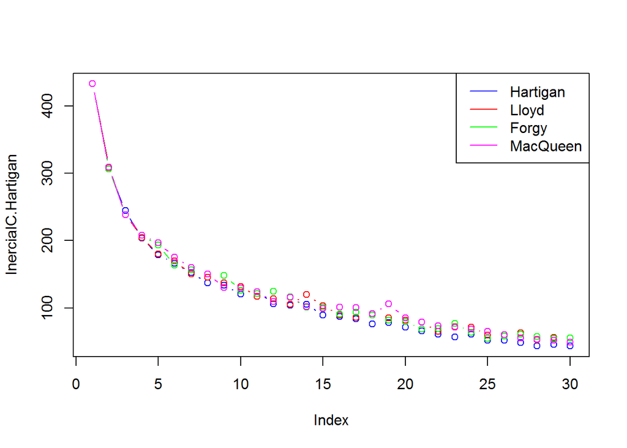

```r
InerciaIC.Hartigan<-rep(0,30)
InerciaIC.Lloyd<-rep(0,30)
InerciaIC.Forgy<-rep(0,30)
InerciaIC.MacQueen<-rep(0,30)
for(k in 1:30) {
   grupos<-kmeans(datos1,k,iter.max=200,algorithm = "Hartigan-Wong")
   InerciaIC.Hartigan[k]<-grupos$tot.withinss
   grupos<-kmeans(datos1,k,iter.max=200,algorithm = "Lloyd")
   InerciaIC.Lloyd[k]<-grupos$tot.withinss
   grupos<-kmeans(datos1,k,iter.max=200,algorithm = "Forgy")
   InerciaIC.Forgy[k]<-grupos$tot.withinss
   grupos<-kmeans(datos1,k,iter.max=200,algorithm = "MacQueen")
   InerciaIC.MacQueen[k]<-grupos$tot.withinss
}
plot(InerciaIC.Hartigan,col="blue",type="b")
points(InerciaIC.Lloyd,col="red",type="b")
points(InerciaIC.Forgy,col="green",type="b")
points(InerciaIC.MacQueen,col="magenta",type="b")
legend("topright",legend = c("Hartigan","Lloyd","Forgy","MacQueen"), col = c("blue",
    "red","green","magenta"), lty = 1, lwd = 1)
```

Según mi interpretación con k=4 se estabiliza la variación de la inercia intra clase.

#### b) Selección de algoritmo para k-medias

```r
Hartigan<-0
Lloyd<-0
Forgy<-0
MacQueen<-0
k<-4
for(i in 1:40) {
  grupos<-kmeans(datos1,k,iter.max=200,algorithm = "Hartigan-Wong")
  Hartigan<-Hartigan+grupos$betweenss
  grupos<-kmeans(datos1,k,iter.max=200,algorithm = "Lloyd")
  Lloyd<-Lloyd+grupos$betweenss
  grupos<-kmeans(datos1,k,iter.max=200,algorithm = "Forgy")
  Forgy<-Forgy+grupos$betweenss
  grupos<-kmeans(datos1,k,iter.max=200,algorithm = "MacQueen")
  MacQueen<-MacQueen+grupos$betweenss
}
Hartigan/40
```

```
## [1] 226.477
```

```r
Lloyd/40
```

```
## [1] 222.2187
```

```r
Forgy/40
```

```
## [1] 220.1022
```

```r
MacQueen/40
```

```
## [1] 223.1932
```

El algoritmo de Hartigan es el que maximiza la inercia inter-clases y por ende minimiza la inercia intra-clases.

#### c) Ejercicio con nstart=100

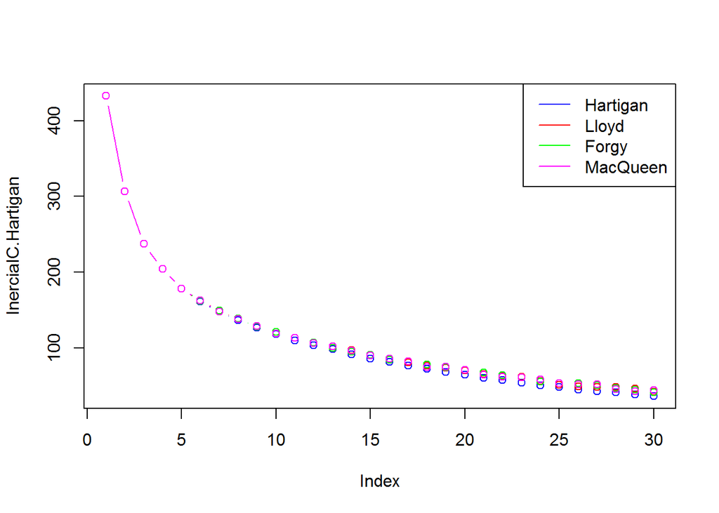

```r
InerciaIC.Hartigan<-rep(0,30)
InerciaIC.Lloyd<-rep(0,30)
InerciaIC.Forgy<-rep(0,30)
InerciaIC.MacQueen<-rep(0,30)
for(k in 1:30) {
   grupos<-kmeans(datos1,k,iter.max=200,nstart=100,algorithm = "Hartigan-Wong")
   InerciaIC.Hartigan[k]<-grupos$tot.withinss
   grupos<-kmeans(datos1,k,iter.max=200,nstart=100,algorithm = "Lloyd")
   InerciaIC.Lloyd[k]<-grupos$tot.withinss
   grupos<-kmeans(datos1,k,iter.max=200,nstart=100,algorithm = "Forgy")
   InerciaIC.Forgy[k]<-grupos$tot.withinss
   grupos<-kmeans(datos1,k,iter.max=200,nstart=100,algorithm = "MacQueen")
   InerciaIC.MacQueen[k]<-grupos$tot.withinss
}
plot(InerciaIC.Hartigan,col="blue",type="b")
points(InerciaIC.Lloyd,col="red",type="b")
points(InerciaIC.Forgy,col="green",type="b")
points(InerciaIC.MacQueen,col="magenta",type="b")
legend("topright",legend = c("Hartigan","Lloyd","Forgy","MacQueen"), col = c("blue",
    "red","green","magenta"), lty = 1, lwd = 1)
```

```r
Hartigan<-0
Lloyd<-0
Forgy<-0
MacQueen<-0
k<-4
for(i in 1:40) {
  grupos<-kmeans(datos1,k,iter.max=200,nstart=100,algorithm = "Hartigan-Wong")
  Hartigan<-Hartigan+grupos$betweenss
  grupos<-kmeans(datos1,k,iter.max=200,nstart=100,algorithm = "Lloyd")
  Lloyd<-Lloyd+grupos$betweenss
  grupos<-kmeans(datos1,k,iter.max=200,nstart=100,algorithm = "Forgy")
  Forgy<-Forgy+grupos$betweenss
  grupos<-kmeans(datos1,k,iter.max=200,nstart=100,algorithm = "MacQueen")
  MacQueen<-MacQueen+grupos$betweenss
}
Hartigan/40
```

```
## [1] 228.8387
```

```r
Lloyd/40
```

```
## [1] 228.646
```

```r
Forgy/40
```

```
## [1] 228.643
```

```r
MacQueen/40
```

```
## [1] 228.6556
```

El parámetro nstart toma múltiples configuraciones iniciales y a partir del resultado se reporta el mejor. El agregar éste parámetro estabiliza la variación de la inercia. Se observa además que usando nstart se logra aumentar la inercia inter clase, esto indica que los clusters están mejor definidos y sus individuos más agrupados entre si.

### **Ejercicio 2**

#### Generación de muestra aleatoria

```r
datos2 <- read.csv("DatosIngresos.csv", header=TRUE, sep=";", dec=",")
str(datos2)
```

```
## 'data.frame':    32561 obs. of  15 variables:
##  $ Age           : int  39 50 38 53 28 37 49 52 31 42 ...
##  $ workclass     : Factor w/ 9 levels " Federal-gov",..: 8 7 5 5 5 5 5 7 5 5 ...
##  $ fnlwgt        : int  77516 83311 215646 234721 338409 284582 160187 209642 45781 159449 ...
##  $ education     : Factor w/ 16 levels " 10th"," 11th",..: 10 10 12 2 10 13 7 12 13 10 ...
##  $ education.num : int  13 13 9 7 13 14 5 9 14 13 ...
##  $ marital.status: Factor w/ 7 levels " Divorced"," Married-AF-spouse",..: 5 3 1 3 3 3 4 3 5 3 ...
##  $ occupation    : Factor w/ 15 levels " Adm-clerical",..: 1 4 6 6 11 4 9 4 11 4 ...
##  $ relationship  : Factor w/ 6 levels " Husband"," Not-in-family",..: 2 1 2 1 6 6 2 1 2 1 ...
##  $ race          : Factor w/ 5 levels " Amer-Indian-Eskimo",..: 5 5 5 3 3 5 3 5 5 5 ...
##  $ sex           : Factor w/ 2 levels " Female"," Male": 2 2 2 2 1 1 1 2 1 2 ...
##  $ capital.gain  : int  2174 0 0 0 0 0 0 0 14084 5178 ...
##  $ capital.loss  : int  0 0 0 0 0 0 0 0 0 0 ...
##  $ hours.per.week: int  40 13 40 40 40 40 16 45 50 40 ...
##  $ native.country: Factor w/ 42 levels " Cambodia"," Canada",..: 40 40 40 40 5 40 23 40 40 40 ...
##  $ Income        : Factor w/ 2 levels " <=50K"," >50K": 1 1 1 1 1 1 1 2 2 2 ...
```

```r
#Dimensión de la tabla original
summary(datos2$Income)
```

```
##  <=50K   >50K
##  24720   7841
```

```r
#Proporción de la tabla original
prop.table(summary(datos2$Income))
```

```
##     <=50K      >50K
## 0.7591904 0.2408096
```

```r
muestra <- sample(dim(datos2)[1], 2000, replace = FALSE)
tmuestra <- datos2[muestra,]
#Dimensión de la tabla original
summary(tmuestra$Income)
```

```
##  <=50K   >50K
##   1518    482
```

```r
#Proporción de la tabla de muetra
prop.table(summary(tmuestra$Income))
```

```
##  <=50K   >50K
##  0.759  0.241
```

#### a) Calibración del modelo ADA

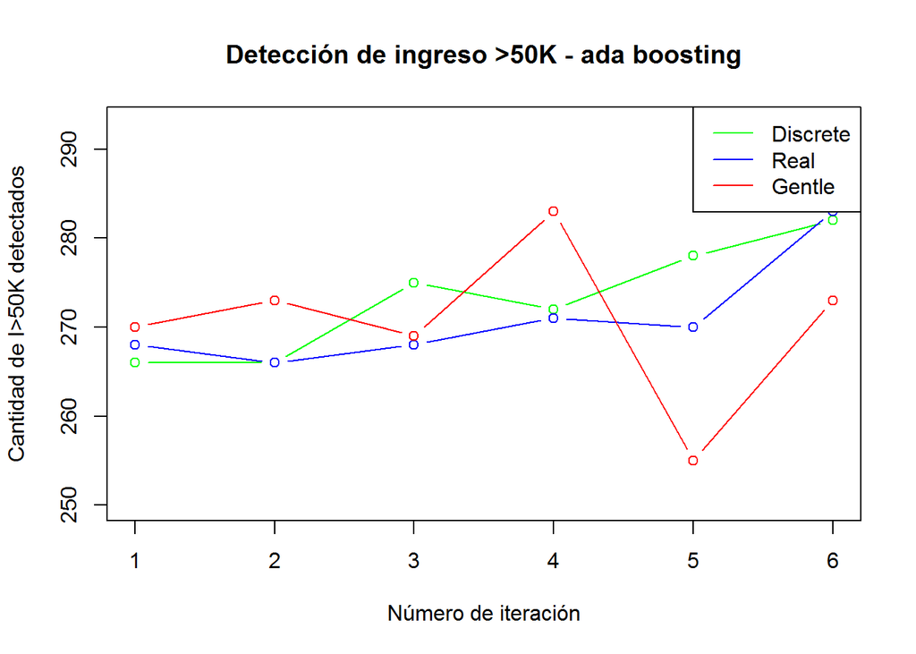

```r
n <- dim(tmuestra)[1]
deteccion.mayor.discrete<-rep(0,6)
deteccion.mayor.real<-rep(0,6)
deteccion.mayor.gentle<-rep(0,6)

# Validación cruzada 6 veces
for(i in 1:6) {
  grupos <- createFolds(1:n,5)
  mayor.discrete<-0
  mayor.real<-0
  mayor.gentle<-0


  for(k in 1:5) {
      muestra <- grupos[[k]]
      ttesting <- tmuestra[muestra,]
      taprendizaje <- tmuestra[-muestra,]

      modelo<-ada(Income~.,data=taprendizaje,iter=60,nu=1,type="discrete")
      prediccion <- predict(modelo,ttesting)
      Actual<-ttesting[,15]
      MC<-table(Actual,prediccion)
      mayor.discrete<- mayor.discrete+MC[2,2]

      modelo<-ada(Income~.,data=taprendizaje,iter=60,nu=1,type="real")
      prediccion <- predict(modelo,ttesting)
      Actual<-ttesting[,15]
      MC<-table(Actual,prediccion)
      mayor.real<- mayor.real+MC[2,2]

      modelo<-ada(Income~.,data=taprendizaje,iter=60,nu=1,type="gentle")
      prediccion <- predict(modelo,ttesting)
      Actual<-ttesting[,15]
      MC<-table(Actual,prediccion)
      mayor.gentle<- mayor.gentle+MC[2,2]
  }

   deteccion.mayor.discrete[i]<-mayor.discrete
   deteccion.mayor.real[i]<-mayor.real
   deteccion.mayor.gentle[i]<-mayor.gentle

}
plot(deteccion.mayor.discrete, col = "green", type = "b",  ylim = c(min(deteccion.mayor.discrete, deteccion.mayor.real, deteccion.mayor.gentle)-5, max(deteccion.mayor.discrete, deteccion.mayor.real, deteccion.mayor.gentle)+10), main = "Detección de ingreso >50K - ada boosting", xlab = "Número de iteración", ylab = "Cantidad de I>50K detectados")
points(deteccion.mayor.real, col = "blue", type = "b")
points(deteccion.mayor.gentle, col = "red", type = "b")
legend("topright", legend = c("Discrete","Real","Gentle"), col = c("green",
    "blue","red"), lty = 1, lwd = 1)
```

#### b) Cálculo de errores globales

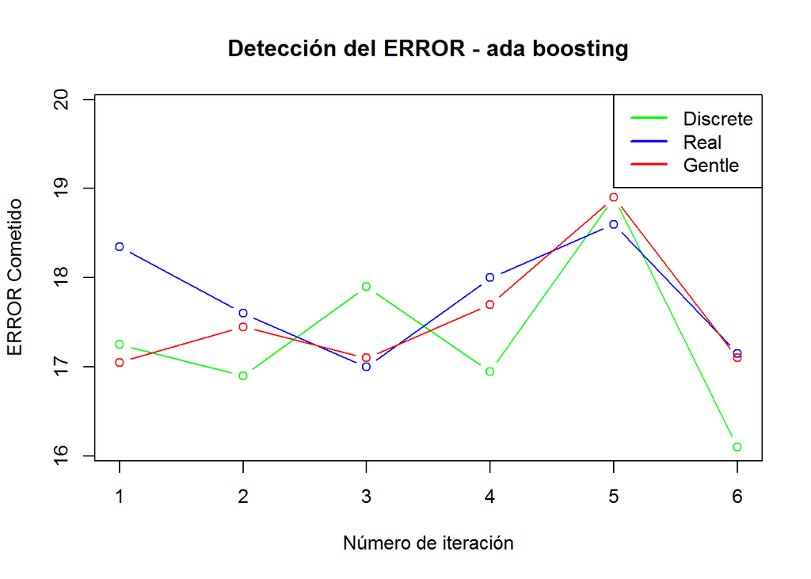

```r
n <- dim(tmuestra)[1]
deteccion.error.discrete<-rep(0,6)
deteccion.error.real<-rep(0,6)
deteccion.error.gentle<-rep(0,6)

for(i in 1:6) {
  grupos <- createFolds(1:n,5)
  error.discrete<-0
  error.real<-0
  error.gentle<-0

  for(k in 1:5) {
      muestra <- grupos[[k]]
      ttesting <- tmuestra[muestra,]
      taprendizaje <- tmuestra[-muestra,]

      modelo<-ada(Income~.,data=taprendizaje,iter=60,nu=1,type="discrete")
      prediccion <- predict(modelo,ttesting)
      Actual<-ttesting[,15]
      MC<-table(Actual,prediccion)
      error.discrete<-error.discrete+(1-(sum(diag(MC)))/sum(MC))*100

      modelo<-ada(Income~.,data=taprendizaje,iter=60,nu=1,type="real")
      prediccion<-predict(modelo,ttesting)
      Actual<-ttesting[,15]
      MC<-table(Actual,prediccion)
      error.real<-error.real+(1-(sum(diag(MC)))/sum(MC))*100

      modelo<-ada(Income~.,data=taprendizaje,iter=60,nu=1,type="gentle")
      prediccion <- predict(modelo, ttesting)
      Actual<-ttesting[,15]
      MC<-table(Actual,prediccion)
      error.gentle<-error.gentle+(1-(sum(diag(MC)))/sum(MC))*100

   }
   deteccion.error.discrete[i]<-error.discrete/5
   deteccion.error.real[i]<-error.real/5
   deteccion.error.gentle[i]<-error.gentle/5

}
plot(deteccion.error.discrete, col = "green", type = "b",  ylim = c(min(deteccion.error.discrete, deteccion.error.real, deteccion.error.gentle), max(deteccion.error.discrete, deteccion.error.real, deteccion.error.gentle)+1), main = "Detección del ERROR - ada boosting", xlab = "Número de iteración", ylab = "ERROR Cometido")
points(deteccion.error.real, col = "blue", type = "b")
points(deteccion.error.gentle, col = "red", type = "b")

legend("topright", legend = c("Discrete","Real","Gentle"), col = c("green","blue","red"), lty = 1, lwd = 2)
```

### **Ejercicio 3**

Para este ejercicio se va a utilizar la muestra de 2000 indiviuos utilizada en el ejercicio 2 (tmuestra). Debido a que ya se calibró el método de Potenciación, se va a proceder a calibrar el resto de métodos, a saber, Bayes, SVM, Arboles, Bosques y Redes Neuronales.

#### a) Predicción Income > 50K

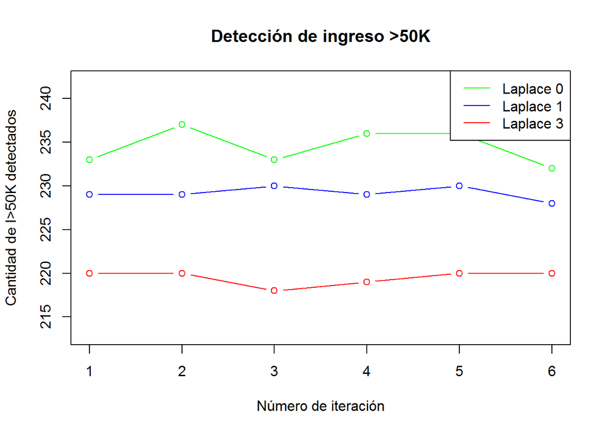

```r
n <- dim(tmuestra)[1]

#Selección del mejor método de Bayes
#Según lo indicado en http://www.learnbymarketing.com/tutorials/naive-bayes-in-r/ se va a variar el parámetro Laplace para ver si tiene algún efecto.

deteccion.mayor.laplace.0<-rep(0,6)
deteccion.mayor.laplace.1<-rep(0,6)
deteccion.mayor.laplace.3<-rep(0,6)

# Validación cruzada 6 veces
for(i in 1:6) {
  grupos <- createFolds(1:n,5)
  mayor.laplace.0<-0
  mayor.laplace.1<-0
  mayor.laplace.3<-0

  for(k in 1:5) {
      muestra <- grupos[[k]]
      ttesting <- tmuestra[muestra,]
      taprendizaje <- tmuestra[-muestra,]

      modelo <- naiveBayes(Income~.,data=taprendizaje,laplace=0)
      prediccion <- predict(modelo,ttesting)
      Actual<-ttesting[,15]
      MC<-table(Actual,prediccion)
      mayor.laplace.0<- mayor.laplace.0+MC[2,2]

      modelo <- naiveBayes(Income~.,data=taprendizaje,laplace=1)
      prediccion <- predict(modelo,ttesting)
      Actual<-ttesting[,15]
      MC<-table(Actual,prediccion)
      mayor.laplace.1<- mayor.laplace.1+MC[2,2]

      modelo <- naiveBayes(Income~.,data=taprendizaje,laplace=3)
      prediccion <- predict(modelo,ttesting)
      Actual<-ttesting[,15]
      MC<-table(Actual,prediccion)
      mayor.laplace.3<- mayor.laplace.3+MC[2,2]
  }

   deteccion.mayor.laplace.0[i]<-mayor.laplace.0
   deteccion.mayor.laplace.1[i]<-mayor.laplace.1
   deteccion.mayor.laplace.3[i]<-mayor.laplace.3

}
plot(deteccion.mayor.laplace.0, col = "green", type = "b",  ylim = c(min(deteccion.mayor.laplace.0, deteccion.mayor.laplace.1, deteccion.mayor.laplace.3)-5, max(deteccion.mayor.laplace.0, deteccion.mayor.laplace.1, deteccion.mayor.laplace.3)+5), main = "Detección de ingreso >50K", xlab = "Número de iteración", ylab = "Cantidad de I>50K detectados")
points(deteccion.mayor.laplace.1, col = "blue", type = "b")
points(deteccion.mayor.laplace.3, col = "red", type = "b")
legend("topright", legend = c("Laplace 0","Laplace 1","Laplace 3"), col = c("green",
    "blue","red"), lty = 1, lwd = 1)
```

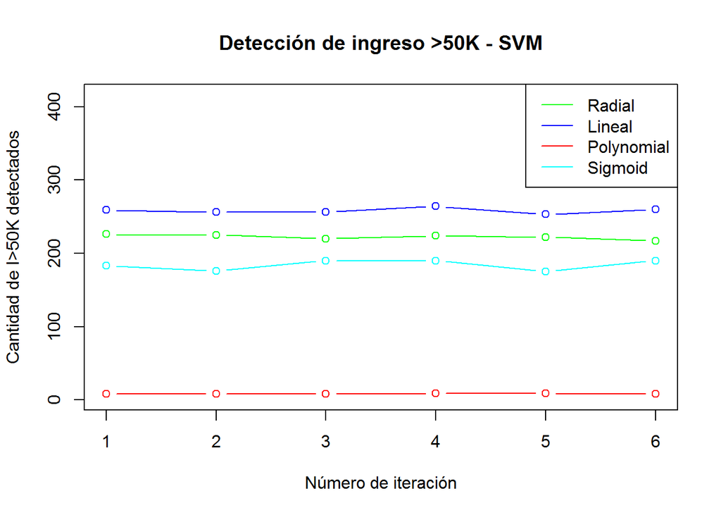

```r
#Selección del mejor método de SVM

deteccion.mayor.radial<-rep(0,6)
deteccion.mayor.lineal<-rep(0,6)
deteccion.mayor.polynomial<-rep(0,6)
deteccion.mayor.sigmoid<-rep(0,6)

# Validación cruzada 6 veces
for(i in 1:6) {
  grupos <- createFolds(1:n,5)
  mayor.radial<-0
  mayor.lineal<-0
  mayor.polynomial<-0
  mayor.sigmoid<-0

  for(k in 1:5) {
      muestra <- grupos[[k]]
      ttesting <- tmuestra[muestra,]
      taprendizaje <- tmuestra[-muestra,]

      modelo <- svm(Income~.,data=taprendizaje,kernel="radial")
      prediccion <- predict(modelo,ttesting)
      Actual<-ttesting[,15]
      MC<-table(Actual,prediccion)
      mayor.radial<- mayor.radial+MC[2,2]

      modelo <- svm(Income~.,data=taprendizaje,kernel="linear")
      prediccion <- predict(modelo,ttesting)
      Actual<-ttesting[,15]
      MC<-table(Actual,prediccion)
      mayor.lineal<- mayor.lineal+MC[2,2]

      modelo <- svm(Income~.,data=taprendizaje,kernel="polynomial")
      prediccion <- predict(modelo,ttesting)
      Actual<-ttesting[,15]
      MC<-table(Actual,prediccion)
      mayor.polynomial<- mayor.polynomial+MC[2,2]

      modelo <- svm(Income~.,data=taprendizaje,kernel="sigmoid")
      prediccion <- predict(modelo,ttesting)
      Actual<-ttesting[,15]
      MC<-table(Actual,prediccion)
      mayor.sigmoid<- mayor.sigmoid+MC[2,2]
  }

   deteccion.mayor.radial[i]<-mayor.radial
   deteccion.mayor.lineal[i]<-mayor.lineal
   deteccion.mayor.polynomial[i]<-mayor.polynomial
   deteccion.mayor.sigmoid[i]<-mayor.sigmoid

}
plot(deteccion.mayor.radial, col = "green", type = "b",  ylim = c(min(deteccion.mayor.radial,deteccion.mayor.lineal,deteccion.mayor.polynomial,deteccion.mayor.sigmoid)-5, max(deteccion.mayor.radial,deteccion.mayor.lineal,deteccion.mayor.polynomial,deteccion.mayor.sigmoid)+150), main = "Detección de ingreso >50K - SVM", xlab = "Número de iteración", ylab = "Cantidad de I>50K detectados")
points(deteccion.mayor.lineal, col = "blue", type = "b")
points(deteccion.mayor.polynomial, col = "red", type = "b")
points(deteccion.mayor.sigmoid, col = "cyan", type = "b")
legend("topright", legend = c("Radial","Lineal","Polynomial","Sigmoid"), col = c("green",
    "blue","red","cyan"), lty = 1, lwd = 1)
```

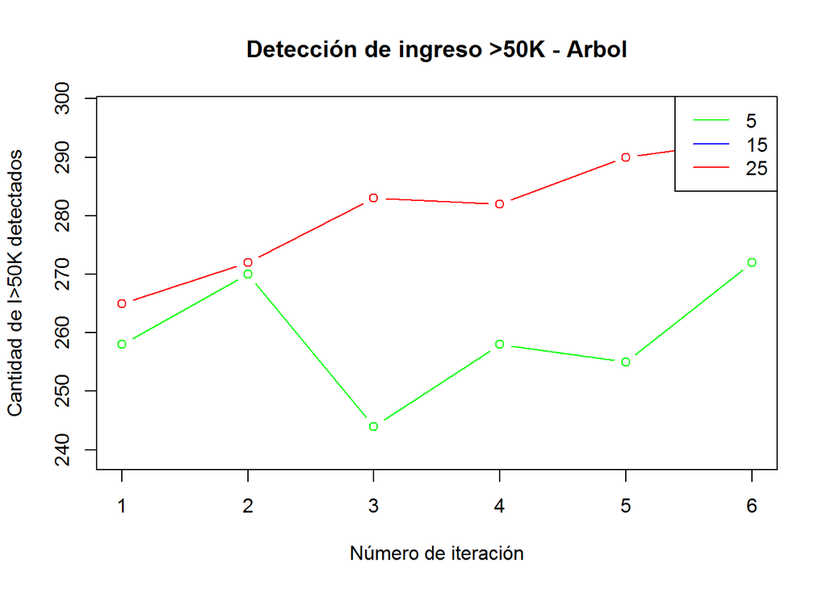

```r
#Selección del mejor método de Arbol
#Se va a variar el parámetro maxdepth (Profundidad Máxima)

deteccion.mayor.arbol.1<-rep(0,6)
deteccion.mayor.arbol.2<-rep(0,6)
deteccion.mayor.arbol.3<-rep(0,6)

# Validación cruzada 6 veces
for(i in 1:6) {
  grupos <- createFolds(1:n,5)
  mayor.arbol.1<-0
  mayor.arbol.2<-0
  mayor.arbol.3<-0

  for(k in 1:5) {
      muestra <- grupos[[k]]
      ttesting <- tmuestra[muestra,]
      taprendizaje <- tmuestra[-muestra,]

      modelo <- rpart(Income~.,data=taprendizaje,control=rpart.control(maxdepth=5))
      prediccion <- predict(modelo,ttesting,type='class')
      Actual<-ttesting[,15]
      MC<-table(Actual,prediccion)
      mayor.arbol.1<- mayor.arbol.1+MC[2,2]

      modelo <- rpart(Income~.,data=taprendizaje,control=rpart.control(maxdepth=15))
      prediccion <- predict(modelo,ttesting,type='class')
      Actual<-ttesting[,15]
      MC<-table(Actual,prediccion)
      mayor.arbol.2<- mayor.arbol.2+MC[2,2]

      modelo <- rpart(Income~.,data=taprendizaje,control=rpart.control(maxdepth=25))
      prediccion <- predict(modelo,ttesting,type='class')
      Actual<-ttesting[,15]
      MC<-table(Actual,prediccion)
      mayor.arbol.3<- mayor.arbol.3+MC[2,2]
  }

   deteccion.mayor.arbol.1[i]<-mayor.arbol.1
   deteccion.mayor.arbol.2[i]<-mayor.arbol.2
   deteccion.mayor.arbol.3[i]<-mayor.arbol.3
}

plot(deteccion.mayor.arbol.1, col = "green", type = "b",  ylim = c(min(deteccion.mayor.arbol.1,deteccion.mayor.arbol.2,deteccion.mayor.arbol.3)-5, max(deteccion.mayor.arbol.1,deteccion.mayor.arbol.2,deteccion.mayor.arbol.3)+5), main = "Detección de ingreso >50K - Arbol", xlab = "Número de iteración", ylab = "Cantidad de I>50K detectados")
points(deteccion.mayor.arbol.2, col = "blue", type = "b")
points(deteccion.mayor.arbol.3, col = "red", type = "b")
legend("topright", legend = c("5","15","25"), col = c("green",
    "blue","red"), lty = 1, lwd = 1)
```

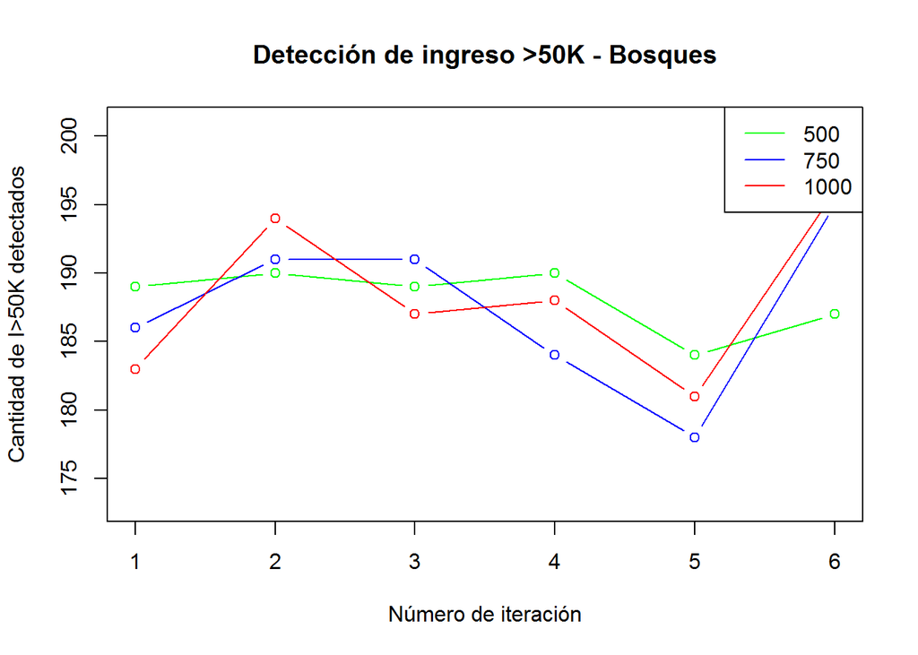

```r
#Selección del mejor método de Bosques
#Se va a variar el parámetro ntree (Número de árboles)

deteccion.mayor.bosques.500<-rep(0,6)
deteccion.mayor.bosques.750<-rep(0,6)
deteccion.mayor.bosques.1000<-rep(0,6)

# Validación cruzada 6 veces
for(i in 1:6) {
  grupos <- createFolds(1:n,5)
  mayor.bosques.500<-0
  mayor.bosques.750<-0
  mayor.bosques.1000<-0

  for(k in 1:5) {
      muestra <- grupos[[k]]
      ttesting <- tmuestra[muestra,]
      taprendizaje <- tmuestra[-muestra,]

      modelo <- randomForest(Income~.,data=taprendizaje,importance=TRUE,ntree=500)
      prediccion <- predict(modelo,ttesting)
      Actual<-ttesting[,15]
      MC<-table(Actual,prediccion)
      mayor.bosques.500<- mayor.bosques.500+MC[2,2]

      modelo <- randomForest(Income~.,data=taprendizaje,importance=TRUE,ntree=750)
      prediccion <- predict(modelo,ttesting)
      Actual<-ttesting[,15]
      MC<-table(Actual,prediccion)
      mayor.bosques.750<- mayor.bosques.750+MC[2,2]

      modelo <- randomForest(Income~.,data=taprendizaje,importance=TRUE,ntree=1000)
      prediccion <- predict(modelo,ttesting)
      Actual<-ttesting[,15]
      MC<-table(Actual,prediccion)
      mayor.bosques.1000<- mayor.bosques.1000+MC[2,2]
  }

   deteccion.mayor.bosques.500[i]<-mayor.bosques.500
   deteccion.mayor.bosques.750[i]<-mayor.bosques.750
   deteccion.mayor.bosques.1000[i]<-mayor.bosques.1000
}

plot(deteccion.mayor.bosques.500, col = "green", type = "b",  ylim = c(min(deteccion.mayor.bosques.500,deteccion.mayor.bosques.750,deteccion.mayor.bosques.1000)-5, max(deteccion.mayor.bosques.500,deteccion.mayor.bosques.750,deteccion.mayor.bosques.1000)+5), main = "Detección de ingreso >50K - Bosques", xlab = "Número de iteración", ylab = "Cantidad de I>50K detectados")
points(deteccion.mayor.bosques.750, col = "blue", type = "b")
points(deteccion.mayor.bosques.1000, col = "red", type = "b")
legend("topright", legend = c("500","750","1000"), col = c("green",
    "blue","red"), lty = 1, lwd = 1)
```

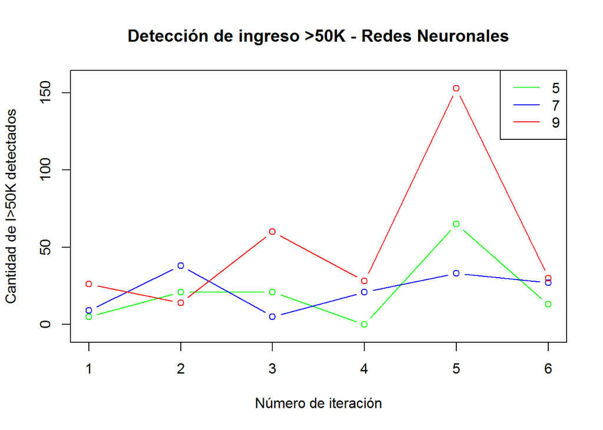

```r
#Selección del mejor método de Redes Neuronales
#Se va a variar el parámetro size (Número de capas ocultas)

deteccion.mayor.redes.1<-rep(0,6)
deteccion.mayor.redes.2<-rep(0,6)
deteccion.mayor.redes.3<-rep(0,6)

# Validación cruzada 6 veces
for(i in 1:6) {
  grupos <- createFolds(1:n,5)
  mayor.redes.1<-0
  mayor.redes.2<-0
  mayor.redes.3<-0

  for(k in 1:5) {
      muestra <- grupos[[k]]
      ttesting <- tmuestra[muestra,]
      taprendizaje <- tmuestra[-muestra,]

      modelo <- nnet(Income~.,data=taprendizaje,size = 5, rang = 0.1,decay = 5e-4, maxit = 100,trace=FALSE)
      prediccion <- predict(modelo,ttesting[,-15],type="class")
      Actual<-ttesting[,15]
      MC<-table(Actual,prediccion)
      if (dim(MC)[2]==1){
      MC<-cbind(MC,c(0,0))
      }
      mayor.redes.1<- mayor.redes.1+MC[2,2]

      modelo <- nnet(Income~.,data=taprendizaje,size = 7, rang = 0.1,decay = 5e-4, maxit = 100,trace=FALSE)
      prediccion <- predict(modelo,ttesting[,-15],type="class")
      Actual<-ttesting[,15]
      MC<-cbind(table(Actual,prediccion),c(0,0))
      if (dim(MC)[2]==1){
      MC<-cbind(MC,c(0,0))
      }
      mayor.redes.2<- mayor.redes.2+MC[2,2]

      modelo <- nnet(Income~.,data=taprendizaje,size = 9, rang = 0.1,decay = 5e-4, maxit = 100,trace=FALSE)
      prediccion <- predict(modelo,ttesting[,-15],type="class")
      Actual<-ttesting[,15]
      MC<-table(Actual,prediccion)
      if (dim(MC)[2]==1){
      MC<-cbind(MC,c(0,0))
      }
      mayor.redes.3<- mayor.redes.3+MC[2,2]
  }

   deteccion.mayor.redes.1[i]<-mayor.redes.1
   deteccion.mayor.redes.2[i]<-mayor.redes.2
   deteccion.mayor.redes.3[i]<-mayor.redes.3
}

plot(deteccion.mayor.redes.1, col = "green", type = "b",  ylim = c(min(deteccion.mayor.redes.1,deteccion.mayor.redes.2,deteccion.mayor.redes.3)-5, max(deteccion.mayor.redes.1,deteccion.mayor.redes.2,deteccion.mayor.redes.3)+5), main = "Detección de ingreso >50K - Redes Neuronales", xlab = "Número de iteración", ylab = "Cantidad de I>50K detectados")
points(deteccion.mayor.redes.2, col = "blue", type = "b")
points(deteccion.mayor.redes.3, col = "red", type = "b")
legend("topright", legend = c("5","7","9"), col = c("green","blue","red"), lty = 1, lwd = 1)
```

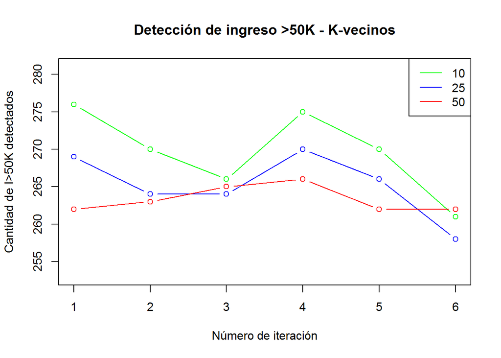

```r
#Selección del mejor método de K-vecinos

deteccion.mayor.k.10<-rep(0,6)
deteccion.mayor.k.25<-rep(0,6)
deteccion.mayor.k.50<-rep(0,6)

# Validación cruzada 6 veces
for(i in 1:6) {
  grupos <- createFolds(1:n,5)
  mayor.k.10<-0
  mayor.k.25<-0
  mayor.k.50<-0


  for(k in 1:5) {
      muestra <- grupos[[k]]
      ttesting <- tmuestra[muestra,]
      taprendizaje <- tmuestra[-muestra,]

      modelo <- train.kknn(Income~.,data=taprendizaje,kmax=10)
      prediccion <- predict(modelo,ttesting)
      Actual<-ttesting[,15]
      MC<-table(Actual,prediccion)
      mayor.k.10<- mayor.k.10+MC[2,2]

      modelo <- train.kknn(Income~.,data=taprendizaje,kmax=25)
      prediccion <- predict(modelo,ttesting)
      Actual<-ttesting[,15]
      MC<-table(Actual,prediccion)
      mayor.k.25<- mayor.k.25+MC[2,2]

      modelo <- train.kknn(Income~.,data=taprendizaje,kmax=50)
      prediccion <- predict(modelo,ttesting)
      Actual<-ttesting[,15]
      MC<-table(Actual,prediccion)
      mayor.k.50<- mayor.k.50+MC[2,2]
  }

   deteccion.mayor.k.10[i]<-mayor.k.10
   deteccion.mayor.k.25[i]<-mayor.k.25
   deteccion.mayor.k.50[i]<-mayor.k.50

}

plot(deteccion.mayor.k.10, col = "green", type = "b",  ylim = c(min(deteccion.mayor.k.10,deteccion.mayor.k.25,deteccion.mayor.k.50)-5, max(deteccion.mayor.k.10,deteccion.mayor.k.25,deteccion.mayor.k.50)+5), main = "Detección de ingreso >50K - K-vecinos", xlab = "Número de iteración", ylab = "Cantidad de I>50K detectados")
points(deteccion.mayor.k.25, col = "blue", type = "b")
points(deteccion.mayor.k.50, col = "red", type = "b")
legend("topright", legend = c("10","25","50"), col = c("green",
    "blue","red"), lty = 1, lwd = 1)
```

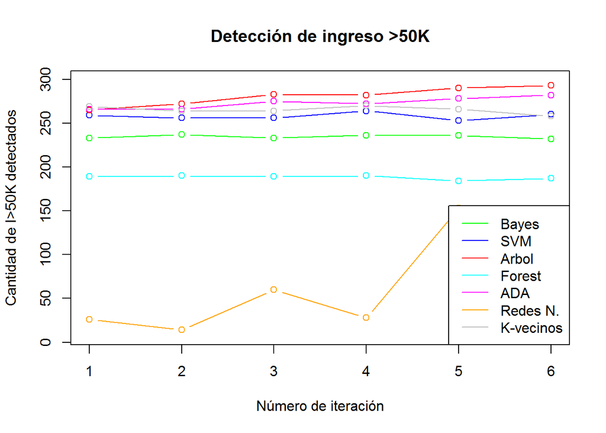

```r
#De acuerdo al análisis anterior se utilizarán los métodos con los siguientes parámetros

#Bayes - Lapace=0
#SVM - kernel="linear"
#Arbol - control=rpart.control(maxdepth=15)
#Forest  -ntree=500
#ADA boosting - type="Discrete"
#Redes Neuronales - size=9
#K-vecinos - kmax=25

plot(deteccion.mayor.laplace.0, col = "green", type = "b",  ylim = c(min(deteccion.mayor.laplace.0,deteccion.mayor.lineal,deteccion.mayor.arbol.2,deteccion.mayor.bosques.500,deteccion.mayor.discrete,deteccion.mayor.redes.3,deteccion.mayor.k.25)-5, max(deteccion.mayor.laplace.0,deteccion.mayor.lineal,deteccion.mayor.arbol.2,deteccion.mayor.bosques.500,deteccion.mayor.real,deteccion.mayor.redes.3,deteccion.mayor.k.25)+5), main = "Detección de ingreso >50K", xlab = "Número de iteración", ylab = "Cantidad de I>50K detectados")
points(deteccion.mayor.lineal, col = "blue", type = "b")
points(deteccion.mayor.arbol.2, col = "red", type = "b")
points(deteccion.mayor.bosques.500, col = "cyan", type = "b")
points(deteccion.mayor.discrete, col = "magenta", type = "b")
points(deteccion.mayor.redes.3, col = "orange", type = "b")
points(deteccion.mayor.k.25, col = "grey", type = "b")
legend("bottomright", legend = c("Bayes","SVM","Arbol","Forest","ADA","Redes N.","K-vecinos"), col = c("green",
    "blue","red","cyan","magenta","orange","grey"), lty = 1, lwd = 1)
```

Aunque es difícil determinar los tres mejores modelos, se puede decir a partir de la gráfica que son: K-vecinos, Ada boosting y Arboles.

#### b) Errores globales

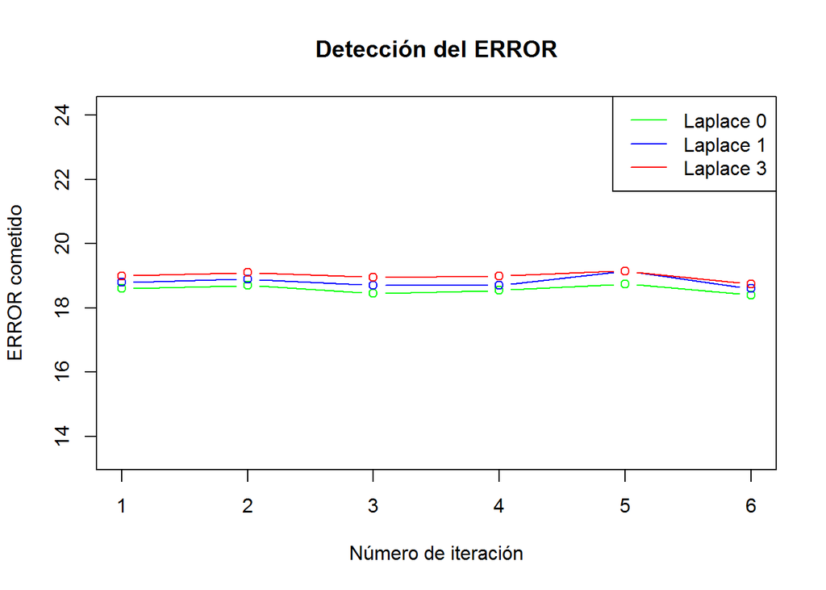

```r
n <- dim(tmuestra)[1]

#Selección del mejor método de Bayes
#Según lo indicado en http://www.learnbymarketing.com/tutorials/naive-bayes-in-r/ se va a variar el parámetro Laplace para ver si tiene algún efecto.

deteccion.error.laplace.0<-rep(0,6)
deteccion.error.laplace.1<-rep(0,6)
deteccion.error.laplace.3<-rep(0,6)

# Validación cruzada 6 veces
for(i in 1:6) {
  grupos <- createFolds(1:n,5)
  error.laplace.0<-0
  error.laplace.1<-0
  error.laplace.3<-0

  for(k in 1:5) {
      muestra <- grupos[[k]]
      ttesting <- tmuestra[muestra,]
      taprendizaje <- tmuestra[-muestra,]

      modelo <- naiveBayes(Income~.,data=taprendizaje,laplace=0)
      prediccion <- predict(modelo,ttesting)
      Actual<-ttesting[,15]
      MC<-table(Actual,prediccion)
      error.laplace.0<-error.laplace.0+(1-(sum(diag(MC)))/sum(MC))*100

      modelo <- naiveBayes(Income~.,data=taprendizaje,laplace=1)
      prediccion <- predict(modelo,ttesting)
      Actual<-ttesting[,15]
      MC<-table(Actual,prediccion)
      error.laplace.1<-error.laplace.1+(1-(sum(diag(MC)))/sum(MC))*100

      modelo <- naiveBayes(Income~.,data=taprendizaje,laplace=3)
      prediccion <- predict(modelo,ttesting)
      Actual<-ttesting[,15]
      MC<-table(Actual,prediccion)
      error.laplace.3<-error.laplace.3+(1-(sum(diag(MC)))/sum(MC))*100
  }

   deteccion.error.laplace.0[i]<-error.laplace.0/5
   deteccion.error.laplace.1[i]<-error.laplace.1/5
   deteccion.error.laplace.3[i]<-error.laplace.3/5

}

plot(deteccion.error.laplace.0, col = "green", type = "b",  ylim = c(min(deteccion.error.laplace.0, deteccion.error.laplace.1, deteccion.error.laplace.3)-5, max(deteccion.error.laplace.0, deteccion.error.laplace.1, deteccion.error.laplace.3)+5), main = "Detección del ERROR", xlab = "Número de iteración", ylab = "ERROR cometido")
points(deteccion.error.laplace.1, col = "blue", type = "b")
points(deteccion.error.laplace.3, col = "red", type = "b")
legend("topright", legend = c("Laplace 0","Laplace 1","Laplace 3"), col = c("green",
    "blue","red"), lty = 1, lwd = 1)
```

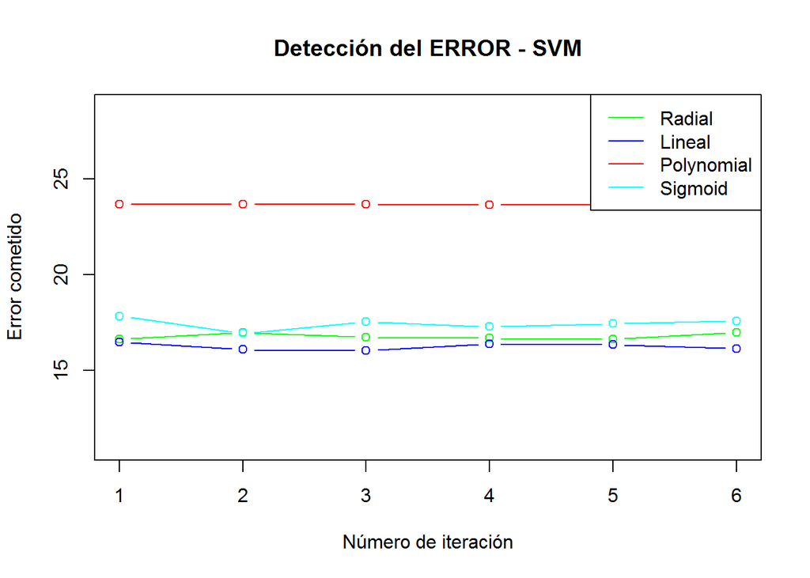

```r
#Selección del mejor método de SVM

deteccion.error.radial<-rep(0,6)
deteccion.error.lineal<-rep(0,6)
deteccion.error.polynomial<-rep(0,6)
deteccion.error.sigmoid<-rep(0,6)

# Validación cruzada 6 veces
for(i in 1:6) {
  grupos <- createFolds(1:n,5)
  error.radial<-0
  error.lineal<-0
  error.polynomial<-0
  error.sigmoid<-0

  for(k in 1:5) {
      muestra <- grupos[[k]]
      ttesting <- tmuestra[muestra,]
      taprendizaje <- tmuestra[-muestra,]

      modelo <- svm(Income~.,data=taprendizaje,kernel="radial")
      prediccion <- predict(modelo,ttesting)
      Actual<-ttesting[,15]
      MC<-table(Actual,prediccion)
      error.radial<-error.radial+(1-(sum(diag(MC)))/sum(MC))*100

      modelo <- svm(Income~.,data=taprendizaje,kernel="linear")
      prediccion <- predict(modelo,ttesting)
      Actual<-ttesting[,15]
      MC<-table(Actual,prediccion)
      error.lineal<-error.lineal+(1-(sum(diag(MC)))/sum(MC))*100

      modelo <- svm(Income~.,data=taprendizaje,kernel="polynomial")
      prediccion <- predict(modelo,ttesting)
      Actual<-ttesting[,15]
      MC<-table(Actual,prediccion)
      error.polynomial<-error.polynomial+(1-(sum(diag(MC)))/sum(MC))*100

      modelo <- svm(Income~.,data=taprendizaje,kernel="sigmoid")
      prediccion <- predict(modelo,ttesting)
      Actual<-ttesting[,15]
      MC<-table(Actual,prediccion)
      error.sigmoid<-error.sigmoid+(1-(sum(diag(MC)))/sum(MC))*100
  }

   deteccion.error.radial[i]<-error.radial/5
   deteccion.error.lineal[i]<-error.lineal/5
   deteccion.error.polynomial[i]<-error.polynomial/5
   deteccion.error.sigmoid[i]<-error.sigmoid/5

}

plot(deteccion.error.radial, col = "green", type = "b",  ylim = c(min(deteccion.error.radial,deteccion.error.lineal,deteccion.error.polynomial,deteccion.error.sigmoid)-5, max(deteccion.error.radial,deteccion.error.lineal,deteccion.error.polynomial,deteccion.error.sigmoid)+5), main = "Detección del ERROR - SVM", xlab = "Número de iteración", ylab = "Error cometido")
points(deteccion.error.lineal, col = "blue", type = "b")
points(deteccion.error.polynomial, col = "red", type = "b")
points(deteccion.error.sigmoid, col = "cyan", type = "b")
legend("topright", legend = c("Radial","Lineal","Polynomial","Sigmoid"), col = c("green",
    "blue","red","cyan"), lty = 1, lwd = 1)
```

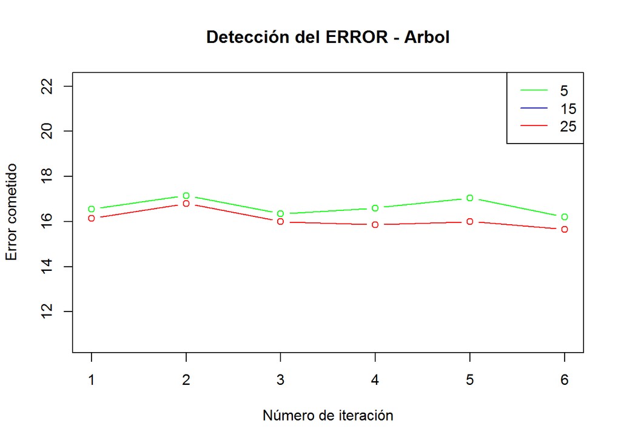

```r
#Selección del mejor método de Arbol
#Se va a variar el parámetro maxdepth (Profundidad Máxima)

deteccion.error.arbol.1<-rep(0,6)
deteccion.error.arbol.2<-rep(0,6)
deteccion.error.arbol.3<-rep(0,6)

# Validación cruzada 6 veces
for(i in 1:6) {
  grupos <- createFolds(1:n,5)
  error.arbol.1<-0
  error.arbol.2<-0
  error.arbol.3<-0

  for(k in 1:5) {
      muestra <- grupos[[k]]
      ttesting <- tmuestra[muestra,]
      taprendizaje <- tmuestra[-muestra,]

      modelo <- rpart(Income~.,data=taprendizaje,control=rpart.control(maxdepth=5))
      prediccion <- predict(modelo,ttesting,type='class')
      Actual<-ttesting[,15]
      MC<-table(Actual,prediccion)
      error.arbol.1<-error.arbol.1+(1-(sum(diag(MC)))/sum(MC))*100

      modelo <- rpart(Income~.,data=taprendizaje,control=rpart.control(maxdepth=15))
      prediccion <- predict(modelo,ttesting,type='class')
      Actual<-ttesting[,15]
      MC<-table(Actual,prediccion)
      error.arbol.2<-error.arbol.2+(1-(sum(diag(MC)))/sum(MC))*100

      modelo <- rpart(Income~.,data=taprendizaje,control=rpart.control(maxdepth=25))
      prediccion <- predict(modelo,ttesting,type='class')
      Actual<-ttesting[,15]
      MC<-table(Actual,prediccion)
      error.arbol.3<-error.arbol.3+(1-(sum(diag(MC)))/sum(MC))*100
  }

   deteccion.error.arbol.1[i]<-error.arbol.1/5
   deteccion.error.arbol.2[i]<-error.arbol.2/5
   deteccion.error.arbol.3[i]<-error.arbol.3/5
}

plot(deteccion.error.arbol.1, col = "green", type = "b",  ylim = c(min(deteccion.error.arbol.1,deteccion.error.arbol.2,deteccion.error.arbol.3)-5, max(deteccion.error.arbol.1,deteccion.error.arbol.2,deteccion.error.arbol.3)+5), main = "Detección del ERROR - Arbol", xlab = "Número de iteración", ylab = "Error cometido")
points(deteccion.error.arbol.2, col = "blue", type = "b")
points(deteccion.error.arbol.3, col = "red", type = "b")
legend("topright", legend = c("5","15","25"), col = c("green",
    "blue","red"), lty = 1, lwd = 1)
```

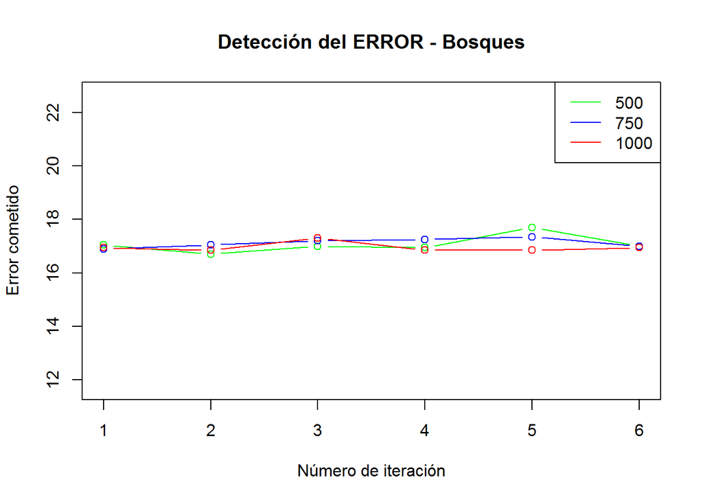

```r
#Selección del mejor método de Bosques
#Se va a variar el parámetro ntree (Número de árboles)


deteccion.error.bosques.500<-rep(0,6)
deteccion.error.bosques.750<-rep(0,6)
deteccion.error.bosques.1000<-rep(0,6)

# Validación cruzada 6 veces
for(i in 1:6) {
  grupos <- createFolds(1:n,5)
  error.bosques.500<-0
  error.bosques.750<-0
  error.bosques.1000<-0

  for(k in 1:5) {
      muestra <- grupos[[k]]
      ttesting <- tmuestra[muestra,]
      taprendizaje <- tmuestra[-muestra,]

      modelo <- randomForest(Income~.,data=taprendizaje,importance=TRUE,ntree=500)
      prediccion <- predict(modelo,ttesting)
      Actual<-ttesting[,15]
      MC<-table(Actual,prediccion)
      error.bosques.500<-error.bosques.500+(1-(sum(diag(MC)))/sum(MC))*100

      modelo <- randomForest(Income~.,data=taprendizaje,importance=TRUE,ntree=750)
      prediccion <- predict(modelo,ttesting)
      Actual<-ttesting[,15]
      MC<-table(Actual,prediccion)
      error.bosques.750<-error.bosques.750+(1-(sum(diag(MC)))/sum(MC))*100

      modelo <- randomForest(Income~.,data=taprendizaje,importance=TRUE,ntree=1000)
      prediccion <- predict(modelo,ttesting)
      Actual<-ttesting[,15]
      MC<-table(Actual,prediccion)
      error.bosques.1000<-error.bosques.1000+(1-(sum(diag(MC)))/sum(MC))*100
  }

   deteccion.error.bosques.500[i]<-error.bosques.500/5
   deteccion.error.bosques.750[i]<-error.bosques.750/5
   deteccion.error.bosques.1000[i]<-error.bosques.1000/5
}

plot(deteccion.error.bosques.500, col = "green", type = "b",  ylim = c(min(deteccion.error.bosques.500,deteccion.error.bosques.750,deteccion.error.bosques.1000)-5, max(deteccion.error.bosques.500,deteccion.error.bosques.750,deteccion.error.bosques.1000)+5), main = "Detección del ERROR - Bosques", xlab = "Número de iteración", ylab = "Error cometido")
points(deteccion.error.bosques.750, col = "blue", type = "b")
points(deteccion.error.bosques.1000, col = "red", type = "b")
legend("topright", legend = c("500","750","1000"), col = c("green",
    "blue","red"), lty = 1, lwd = 1)
```

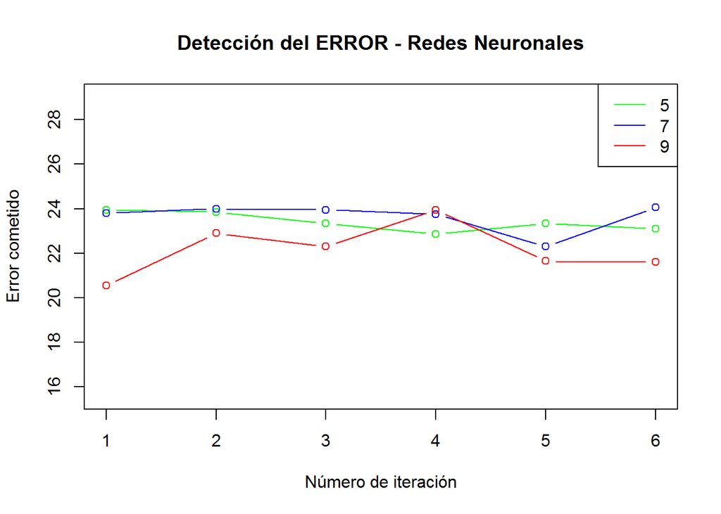

```r
#Selección del mejor método de Redes Neuronales
#Se va a variar el parámetro size (Número de capas ocultas)

deteccion.error.redes.1<-rep(0,6)
deteccion.error.redes.2<-rep(0,6)
deteccion.error.redes.3<-rep(0,6)

# Validación cruzada 6 veces
for(i in 1:6) {
  grupos <- createFolds(1:n,5)
  error.redes.1<-0
  error.redes.2<-0
  error.redes.3<-0

  for(k in 1:5) {
      muestra <- grupos[[k]]
      ttesting <- tmuestra[muestra,]
      taprendizaje <- tmuestra[-muestra,]

      modelo <- nnet(Income~.,data=taprendizaje,size = 5, rang = 0.1,decay = 5e-4, maxit = 100,trace=FALSE)
      prediccion <- predict(modelo,ttesting[,-15],type="class")
      Actual<-ttesting[,15]
      MC<-table(Actual,prediccion)
      if (dim(MC)[2]==1){
      MC<-cbind(MC,c(0,0))
      }
      error.redes.1<-error.redes.1+(1-(sum(diag(MC)))/sum(MC))*100

      modelo <- nnet(Income~.,data=taprendizaje,size = 7, rang = 0.1,decay = 5e-4, maxit = 100,trace=FALSE)
      prediccion <- predict(modelo,ttesting[,-15],type="class")
      Actual<-ttesting[,15]
      MC<-cbind(table(Actual,prediccion),c(0,0))
      if (dim(MC)[2]==1){
      MC<-cbind(MC,c(0,0))
      }
      error.redes.2<-error.redes.2+(1-(sum(diag(MC)))/sum(MC))*100

      modelo <- nnet(Income~.,data=taprendizaje,size = 9, rang = 0.1,decay = 5e-4, maxit = 100,trace=FALSE)
      prediccion <- predict(modelo,ttesting[,-15],type="class")
      Actual<-ttesting[,15]
      MC<-table(Actual,prediccion)
      if (dim(MC)[2]==1){
      MC<-cbind(MC,c(0,0))
      }
      error.redes.3<-error.redes.3+(1-(sum(diag(MC)))/sum(MC))*100
  }

   deteccion.error.redes.1[i]<-error.redes.1/5
   deteccion.error.redes.2[i]<-error.redes.2/5
   deteccion.error.redes.3[i]<-error.redes.3/5
}

plot(deteccion.error.redes.1, col = "green", type = "b",  ylim = c(min(deteccion.error.redes.1,deteccion.error.redes.2,deteccion.error.redes.3)-5, max(deteccion.error.redes.1,deteccion.error.redes.2,deteccion.error.redes.3)+5), main = "Detección del ERROR - Redes Neuronales", xlab = "Número de iteración", ylab = "Error cometido")
points(deteccion.error.redes.2, col = "blue", type = "b")
points(deteccion.error.redes.3, col = "red", type = "b")
legend("topright", legend = c("5","7","9"), col = c("green","blue","red"), lty = 1, lwd = 1)
```

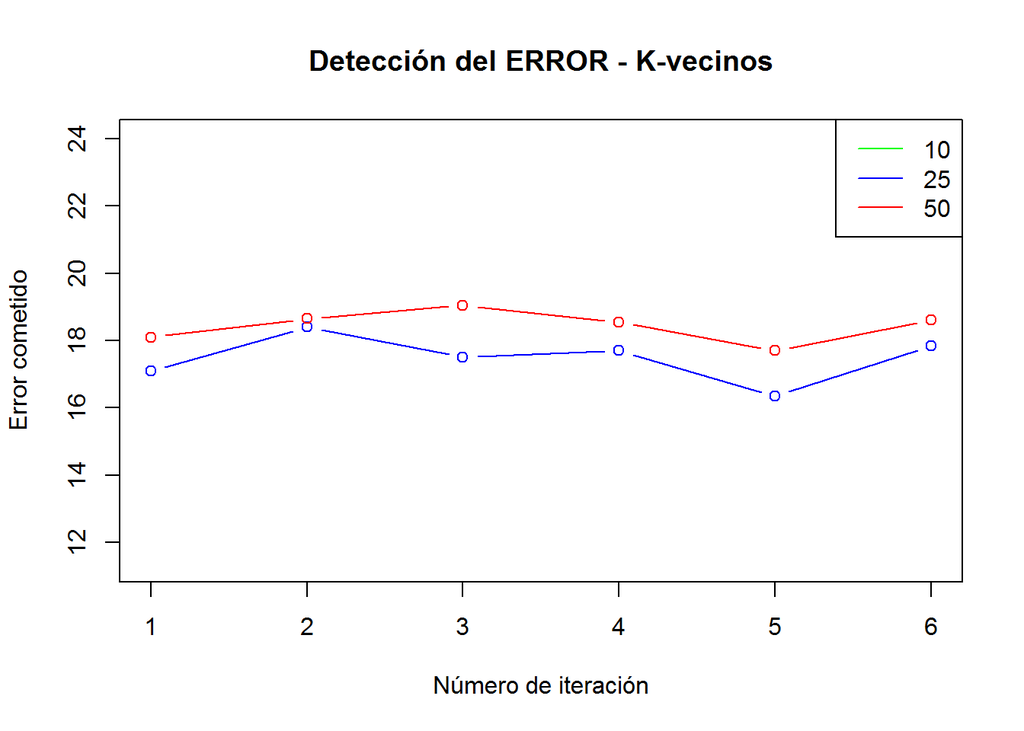

```r
#Selección del mejor método de K-vecinos

deteccion.error.k.10<-rep(0,6)
deteccion.error.k.25<-rep(0,6)
deteccion.error.k.50<-rep(0,6)

# Validación cruzada 6 veces
for(i in 1:6) {
  grupos <- createFolds(1:n,5)
  error.k.10<-0
  error.k.25<-0
  error.k.50<-0


  for(k in 1:5) {
      muestra <- grupos[[k]]
      ttesting <- tmuestra[muestra,]
      taprendizaje <- tmuestra[-muestra,]

      modelo <- train.kknn(Income~.,data=taprendizaje,kmax=10)
      prediccion <- predict(modelo,ttesting)
      Actual<-ttesting[,15]
      MC<-table(Actual,prediccion)
      error.k.10<-error.k.10+(1-(sum(diag(MC)))/sum(MC))*100

      modelo <- train.kknn(Income~.,data=taprendizaje,kmax=25)
      prediccion <- predict(modelo,ttesting)
      Actual<-ttesting[,15]
      MC<-table(Actual,prediccion)
      error.k.25<-error.k.25+(1-(sum(diag(MC)))/sum(MC))*100

      modelo <- train.kknn(Income~.,data=taprendizaje,kmax=50)
      prediccion <- predict(modelo,ttesting)
      Actual<-ttesting[,15]
      MC<-table(Actual,prediccion)
      error.k.50<-error.k.50+(1-(sum(diag(MC)))/sum(MC))*100
  }

   deteccion.error.k.10[i]<-error.k.10/5
   deteccion.error.k.25[i]<-error.k.25/5
   deteccion.error.k.50[i]<-error.k.10/5

}

plot(deteccion.error.k.10, col = "green", type = "b",  ylim = c(min(deteccion.error.k.10,deteccion.error.k.25,deteccion.error.k.50)-5, max(deteccion.error.k.10,deteccion.error.k.25,deteccion.error.k.50)+5), main = "Detección del ERROR - K-vecinos", xlab = "Número de iteración", ylab = "Error cometido")
points(deteccion.error.k.25, col = "blue", type = "b")
points(deteccion.error.k.50, col = "red", type = "b")
legend("topright", legend = c("10","25","50"), col = c("green",
    "blue","red"), lty = 1, lwd = 1)
```

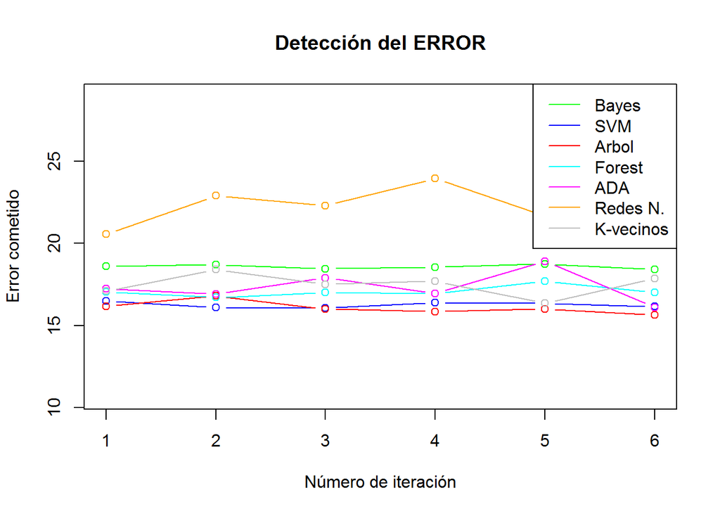

```r
#De acuerdo al análisis anterior se utilizarán los métodos con los siguientes parámetros

#Bayes - Lapace=0
#SVM - kernel="linear"
#Arbol - control=rpart.control(maxdepth=15)
#Forest  -ntree=500
#ADA boosting - type="Discrete"
#Redes Neuronales - size=9
#K-vecinos - kmax=25

plot(deteccion.error.laplace.0, col = "green", type = "b",  ylim = c(min(deteccion.error.laplace.0,deteccion.error.lineal,deteccion.error.arbol.2,deteccion.error.bosques.500,deteccion.error.discrete,deteccion.error.redes.3,deteccion.error.k.25)-5, max(deteccion.error.laplace.0,deteccion.error.lineal,deteccion.error.arbol.2,deteccion.error.bosques.500,deteccion.error.real,deteccion.error.redes.3,deteccion.error.k.25)+5), main = "Detección del ERROR", xlab = "Número de iteración", ylab = "Error cometido")
points(deteccion.error.lineal, col = "blue", type = "b")
points(deteccion.error.arbol.2, col = "red", type = "b")
points(deteccion.error.bosques.500, col = "cyan", type = "b")
points(deteccion.error.discrete, col = "magenta", type = "b")
points(deteccion.error.redes.3, col = "orange", type = "b")
points(deteccion.error.k.25, col = "grey", type = "b")
legend("topright", legend = c("Bayes","SVM","Arbol","Forest","ADA","Redes N.","K-vecinos"), col = c("green","blue","red","cyan","magenta","orange","grey"), lty = 1, lwd = 1)
```

#### c) Errores globales

De acuerdo a lo anterior utilizaría el método de SVM ya que minimiza bastante bien el error global y tiene poca variación a lo largo de las 6 variaciones cruzadas.

### **Ejercicio 4**

#### Carga de datos

Debido a lo desbalanceado del problema se va a hacer uso de toda la tabla de datos para la selección y caliubración del modelo.

```r
datos4 <- read.csv("SegurosV2016.csv", header=TRUE, sep=";", dec=",")
str(datos4)
```

```
## 'data.frame':    6413 obs. of  12 variables:
##  $ Interes       : int  17 17 12 17 17 17 17 17 18 17 ...
##  $ Tipo          : Factor w/ 2 levels "Internacional",..: 2 2 2 2 2 2 2 2 2 2 ...
##  $ MontoAsegurado: int  462045 310530 606894 3037803 650227 462045 310530 613561 189318 3187842 ...
##  $ TipoPago      : Factor w/ 3 levels "A","B","C": 1 1 1 2 1 2 1 1 1 2 ...
##  $ ModoPago      : Factor w/ 3 levels "Cajas","NoDefinido",..: 3 3 3 3 3 3 3 3 3 3 ...
##  $ Fiador        : Factor w/ 2 levels "No","Si": 1 2 1 1 2 2 1 1 1 1 ...
##  $ Fiador2       : Factor w/ 2 levels "No","Si": 1 2 1 1 1 1 1 1 1 1 ...
##  $ OtroSeguro    : Factor w/ 2 levels "No","Si": 2 2 2 1 1 1 1 1 1 1 ...
##  $ Record        : Factor w/ 8 levels "R0","R1","R2",..: 3 2 3 1 1 1 1 1 1 1 ...
##  $ Edad          : int  39 32 32 40 32 34 33 38 35 39 ...
##  $ EstadoCivil   : Factor w/ 5 levels "Divorciado","NoAplica",..: 3 3 3 3 3 3 3 3 3 3 ...
##  $ Fraude        : Factor w/ 2 levels "No","Si": 1 1 1 1 1 1 1 1 1 1 ...
```

```r
#Dimensión de la tabla original
summary(datos4$Fraude)
```

```
##   No   Si
## 6146  267
```

```r
#Proporción de la tabla original
prop.table(summary(datos4$Fraude))
```

```
##         No         Si
## 0.95836582 0.04163418
```

#### Calibración de los métodos

```r
n <- dim(datos4)[1]

deteccion.mayor.laplace.0<-rep(0,6)
deteccion.mayor.laplace.1<-rep(0,6)
deteccion.mayor.laplace.3<-rep(0,6)
deteccion.mayor.radial<-rep(0,6)
deteccion.mayor.lineal<-rep(0,6)
deteccion.mayor.polynomial<-rep(0,6)
deteccion.mayor.sigmoid<-rep(0,6)
deteccion.mayor.arbol.1<-rep(0,6)
deteccion.mayor.arbol.2<-rep(0,6)
deteccion.mayor.arbol.3<-rep(0,6)
deteccion.mayor.bosques.500<-rep(0,6)
deteccion.mayor.bosques.750<-rep(0,6)
deteccion.mayor.bosques.1000<-rep(0,6)
deteccion.mayor.redes.1<-rep(0,6)
deteccion.mayor.redes.2<-rep(0,6)
deteccion.mayor.redes.3<-rep(0,6)
deteccion.mayor.k.10<-rep(0,6)
deteccion.mayor.k.25<-rep(0,6)
deteccion.mayor.k.50<-rep(0,6)
deteccion.mayor.discrete<-rep(0,6)
deteccion.mayor.real<-rep(0,6)
deteccion.mayor.gentle<-rep(0,6)
deteccion.error.laplace.0<-rep(0,6)
deteccion.error.laplace.1<-rep(0,6)
deteccion.error.laplace.3<-rep(0,6)
deteccion.error.radial<-rep(0,6)
deteccion.error.lineal<-rep(0,6)
deteccion.error.polynomial<-rep(0,6)
deteccion.error.sigmoid<-rep(0,6)
deteccion.error.arbol.1<-rep(0,6)
deteccion.error.arbol.2<-rep(0,6)
deteccion.error.arbol.3<-rep(0,6)
deteccion.error.bosques.500<-rep(0,6)
deteccion.error.bosques.750<-rep(0,6)
deteccion.error.bosques.1000<-rep(0,6)
deteccion.error.redes.1<-rep(0,6)
deteccion.error.redes.2<-rep(0,6)
deteccion.error.redes.3<-rep(0,6)
deteccion.error.k.10<-rep(0,6)
deteccion.error.k.25<-rep(0,6)
deteccion.error.k.50<-rep(0,6)
deteccion.error.discrete<-rep(0,6)
deteccion.error.real<-rep(0,6)
deteccion.error.gentle<-rep(0,6)




# Validación cruzada 6 veces
for(i in 1:6) {
  grupos <- createFolds(1:n,5)
  mayor.laplace.0<-0
  mayor.laplace.1<-0
  mayor.laplace.3<-0
  mayor.radial<-0
  mayor.lineal<-0
  mayor.polynomial<-0
  mayor.sigmoid<-0
  mayor.arbol.1<-0
  mayor.arbol.2<-0
  mayor.arbol.3<-0
  mayor.bosques.500<-0
  mayor.bosques.750<-0
  mayor.bosques.1000<-0
  mayor.redes.1<-0
  mayor.redes.2<-0
  mayor.redes.3<-0
  mayor.k.10<-0
  mayor.k.25<-0
  mayor.k.50<-0
  mayor.discrete<-0
  mayor.real<-0
  mayor.gentle<-0
  error.laplace.0<-0
  error.laplace.1<-0
  error.laplace.3<-0
  error.radial<-0
  error.lineal<-0
  error.polynomial<-0
  error.sigmoid<-0
  error.arbol.1<-0
  error.arbol.2<-0
  error.arbol.3<-0
  error.bosques.500<-0
  error.bosques.750<-0
  error.bosques.1000<-0
  error.redes.1<-0
  error.redes.2<-0
  error.redes.3<-0
  error.k.10<-0
  error.k.25<-0
  error.k.50<-0
  error.discrete<-0
  error.real<-0
  error.gentle<-0




  for(k in 1:5) {
      muestra <- grupos[[k]]
      ttesting <- datos4[muestra,]
      taprendizaje <- datos4[-muestra,]

      modelo <- naiveBayes(Fraude~.,data=taprendizaje,laplace=0)
      prediccion <- predict(modelo,ttesting)
      Actual<-ttesting[,12]
      MC<-table(Actual,prediccion)
      mayor.laplace.0<- mayor.laplace.0+MC[2,2]
      error.laplace.0<-error.laplace.0+(1-(sum(diag(MC)))/sum(MC))*100

      modelo <- naiveBayes(Fraude~.,data=taprendizaje,laplace=1)
      prediccion <- predict(modelo,ttesting)
      Actual<-ttesting[,12]
      MC<-table(Actual,prediccion)
      mayor.laplace.1<- mayor.laplace.1+MC[2,2]
      error.laplace.1<-error.laplace.1+(1-(sum(diag(MC)))/sum(MC))*100

      modelo <- naiveBayes(Fraude~.,data=taprendizaje,laplace=3)
      prediccion <- predict(modelo,ttesting)
      Actual<-ttesting[,12]
      MC<-table(Actual,prediccion)
      mayor.laplace.3<- mayor.laplace.3+MC[2,2]
      error.laplace.3<-error.laplace.3+(1-(sum(diag(MC)))/sum(MC))*100

      modelo <- svm(Fraude~.,data=taprendizaje,kernel="radial")
      prediccion <- predict(modelo,ttesting)
      Actual<-ttesting[,12]
      MC<-table(Actual,prediccion)
      mayor.radial<- mayor.radial+MC[2,2]
      error.radial<-error.radial+(1-(sum(diag(MC)))/sum(MC))*100

      modelo <- svm(Fraude~.,data=taprendizaje,kernel="linear")
      prediccion <- predict(modelo,ttesting)
      Actual<-ttesting[,12]
      MC<-table(Actual,prediccion)
      mayor.lineal<- mayor.lineal+MC[2,2]
      error.lineal<-error.lineal+(1-(sum(diag(MC)))/sum(MC))*100

      modelo <- svm(Fraude~.,data=taprendizaje,kernel="polynomial")
      prediccion <- predict(modelo,ttesting)
      Actual<-ttesting[,12]
      MC<-table(Actual,prediccion)
      mayor.polynomial<- mayor.polynomial+MC[2,2]
      error.polynomial<-error.polynomial+(1-(sum(diag(MC)))/sum(MC))*100

      modelo <- svm(Fraude~.,data=taprendizaje,kernel="sigmoid")
      prediccion <- predict(modelo,ttesting)
      Actual<-ttesting[,12]
      MC<-table(Actual,prediccion)
      mayor.sigmoid<- mayor.sigmoid+MC[2,2]
      error.sigmoid<-error.sigmoid+(1-(sum(diag(MC)))/sum(MC))*100

      modelo <- rpart(Fraude~.,data=taprendizaje,control=rpart.control(maxdepth=5))
      prediccion <- predict(modelo,ttesting,type='class')
      Actual<-ttesting[,12]
      MC<-table(Actual,prediccion)
      mayor.arbol.1<- mayor.arbol.1+MC[2,2]
      error.arbol.1<-error.arbol.1+(1-(sum(diag(MC)))/sum(MC))*100

      modelo <- rpart(Fraude~.,data=taprendizaje,control=rpart.control(maxdepth=15))
      prediccion <- predict(modelo,ttesting,type='class')
      Actual<-ttesting[,12]
      MC<-table(Actual,prediccion)
      mayor.arbol.2<- mayor.arbol.2+MC[2,2]
      error.arbol.2<-error.arbol.2+(1-(sum(diag(MC)))/sum(MC))*100

      modelo <- rpart(Fraude~.,data=taprendizaje,control=rpart.control(maxdepth=25))
      prediccion <- predict(modelo,ttesting,type='class')
      Actual<-ttesting[,12]
      MC<-table(Actual,prediccion)
      mayor.arbol.3<- mayor.arbol.3+MC[2,2]
      error.arbol.3<-error.arbol.3+(1-(sum(diag(MC)))/sum(MC))*100

      modelo <- randomForest(Fraude~.,data=taprendizaje,importance=TRUE,ntree=500)
      prediccion <- predict(modelo,ttesting)
      Actual<-ttesting[,12]
      MC<-table(Actual,prediccion)
      mayor.bosques.500<- mayor.bosques.500+MC[2,2]
      error.bosques.500<-error.bosques.500+(1-(sum(diag(MC)))/sum(MC))*100

      modelo <- randomForest(Fraude~.,data=taprendizaje,importance=TRUE,ntree=750)
      prediccion <- predict(modelo,ttesting)
      Actual<-ttesting[,12]
      MC<-table(Actual,prediccion)
      mayor.bosques.750<- mayor.bosques.750+MC[2,2]
      error.bosques.750<-error.bosques.750+(1-(sum(diag(MC)))/sum(MC))*100

      modelo <- randomForest(Fraude~.,data=taprendizaje,importance=TRUE,ntree=1000)
      prediccion <- predict(modelo,ttesting)
      Actual<-ttesting[,12]
      MC<-table(Actual,prediccion)
      mayor.bosques.1000<- mayor.bosques.1000+MC[2,2]
      error.bosques.1000<-error.bosques.1000+(1-(sum(diag(MC)))/sum(MC))*100

      modelo <- nnet(Fraude~.,data=taprendizaje,size = 5, rang = 0.1,decay = 5e-4, maxit = 100,trace=FALSE)
      prediccion <- predict(modelo,ttesting[,-15],type="class")
      Actual<-ttesting[,12]
      MC<-table(Actual,prediccion)
      if (dim(MC)[2]==1){
      MC<-cbind(MC,c(0,0))
      }
      mayor.redes.1<- mayor.redes.1+MC[2,2]
      error.redes.1<-error.redes.1+(1-(sum(diag(MC)))/sum(MC))*100

      modelo <- nnet(Fraude~.,data=taprendizaje,size = 7, rang = 0.1,decay = 5e-4, maxit = 100,trace=FALSE)
      prediccion <- predict(modelo,ttesting[,-15],type="class")
      Actual<-ttesting[,12]
      MC<-cbind(table(Actual,prediccion),c(0,0))
      if (dim(MC)[2]==1){
      MC<-cbind(MC,c(0,0))
      }
      mayor.redes.2<- mayor.redes.2+MC[2,2]
      error.redes.2<-error.redes.2+(1-(sum(diag(MC)))/sum(MC))*100

      modelo <- nnet(Fraude~.,data=taprendizaje,size = 9, rang = 0.1,decay = 5e-4, maxit = 100,trace=FALSE)
      prediccion <- predict(modelo,ttesting[,-15],type="class")
      Actual<-ttesting[,12]
      MC<-table(Actual,prediccion)
      if (dim(MC)[2]==1){
      MC<-cbind(MC,c(0,0))
      }
      mayor.redes.3<- mayor.redes.3+MC[2,2]
      error.redes.3<-error.redes.3+(1-(sum(diag(MC)))/sum(MC))*100

      modelo <- train.kknn(Fraude~.,data=taprendizaje,kmax=2)
      prediccion <- predict(modelo,ttesting)
      Actual<-ttesting[,12]
      MC<-table(Actual,prediccion)
      mayor.k.10<- mayor.k.10+MC[2,2]
      error.k.10<-error.k.10+(1-(sum(diag(MC)))/sum(MC))*100

      modelo <- train.kknn(Fraude~.,data=taprendizaje,kmax=10)
      prediccion <- predict(modelo,ttesting)
      Actual<-ttesting[,12]
      MC<-table(Actual,prediccion)
      mayor.k.25<- mayor.k.25+MC[2,2]
      error.k.25<-error.k.25+(1-(sum(diag(MC)))/sum(MC))*100

      modelo <- train.kknn(Fraude~.,data=taprendizaje,kmax=15)
      prediccion <- predict(modelo,ttesting)
      Actual<-ttesting[,12]
      MC<-table(Actual,prediccion)
      mayor.k.50<- mayor.k.50+MC[2,2]
      error.k.50<-error.k.50+(1-(sum(diag(MC)))/sum(MC))*100

      modelo<-ada(Fraude~.,data=taprendizaje,iter=60,nu=1,type="discrete")
      prediccion <- predict(modelo,ttesting)
      Actual<-ttesting[,12]
      MC<-table(Actual,prediccion)
      mayor.discrete<- mayor.discrete+MC[2,2]
      error.discrete<-error.discrete+(1-(sum(diag(MC)))/sum(MC))*100

      modelo<-ada(Fraude~.,data=taprendizaje,iter=60,nu=1,type="real")
      prediccion <- predict(modelo,ttesting)
      Actual<-ttesting[,12]
      MC<-table(Actual,prediccion)
      mayor.real<- mayor.real+MC[2,2]
      error.real<-error.real+(1-(sum(diag(MC)))/sum(MC))*100

      modelo<-ada(Fraude~.,data=taprendizaje,iter=60,nu=1,type="gentle")
      prediccion <- predict(modelo,ttesting)
      Actual<-ttesting[,12]
      MC<-table(Actual,prediccion)
      mayor.gentle<- mayor.gentle+MC[2,2]
      error.gentle<-error.gentle+(1-(sum(diag(MC)))/sum(MC))*100

  }

   deteccion.mayor.laplace.0[i]<-mayor.laplace.0
   deteccion.mayor.laplace.1[i]<-mayor.laplace.1
   deteccion.mayor.laplace.3[i]<-mayor.laplace.3
   deteccion.mayor.radial[i]<-mayor.radial
   deteccion.mayor.lineal[i]<-mayor.lineal
   deteccion.mayor.polynomial[i]<-mayor.polynomial
   deteccion.mayor.sigmoid[i]<-mayor.sigmoid
   deteccion.mayor.arbol.1[i]<-mayor.arbol.1
   deteccion.mayor.arbol.2[i]<-mayor.arbol.2
   deteccion.mayor.arbol.3[i]<-mayor.arbol.3
   deteccion.mayor.bosques.500[i]<-mayor.bosques.500
   deteccion.mayor.bosques.750[i]<-mayor.bosques.750
   deteccion.mayor.bosques.1000[i]<-mayor.bosques.1000
   deteccion.mayor.redes.1[i]<-mayor.redes.1
   deteccion.mayor.redes.2[i]<-mayor.redes.2
   deteccion.mayor.redes.3[i]<-mayor.redes.3
   deteccion.mayor.k.10[i]<-mayor.k.10
   deteccion.mayor.k.25[i]<-mayor.k.25
   deteccion.mayor.k.50[i]<-mayor.k.50
   deteccion.mayor.discrete[i]<-mayor.discrete
   deteccion.mayor.real[i]<-mayor.real
   deteccion.mayor.gentle[i]<-mayor.gentle
   deteccion.error.laplace.0[i]<-error.laplace.0/5
   deteccion.error.laplace.1[i]<-error.laplace.1/5
   deteccion.error.laplace.3[i]<-error.laplace.3/5
   deteccion.error.radial[i]<-error.radial/5
   deteccion.error.lineal[i]<-error.lineal/5
   deteccion.error.polynomial[i]<-error.polynomial/5
   deteccion.error.sigmoid[i]<-error.sigmoid/5
   deteccion.error.arbol.1[i]<-error.arbol.1/5
   deteccion.error.arbol.2[i]<-error.arbol.2/5
   deteccion.error.arbol.3[i]<-error.arbol.3/5
   deteccion.error.bosques.500[i]<-error.bosques.500/5
   deteccion.error.bosques.750[i]<-error.bosques.750/5
   deteccion.error.bosques.1000[i]<-error.bosques.1000/5
   deteccion.error.redes.1[i]<-error.redes.1/5
   deteccion.error.redes.2[i]<-error.redes.2/5
   deteccion.error.redes.3[i]<-error.redes.3/5
   deteccion.error.k.10[i]<-error.k.10/5
   deteccion.error.k.25[i]<-error.k.25/5
   deteccion.error.k.50[i]<-error.k.50/5
   deteccion.error.discrete[i]<-error.discrete/5
   deteccion.error.real[i]<-error.real/5
   deteccion.error.gentle[i]<-error.gentle/5


}
```

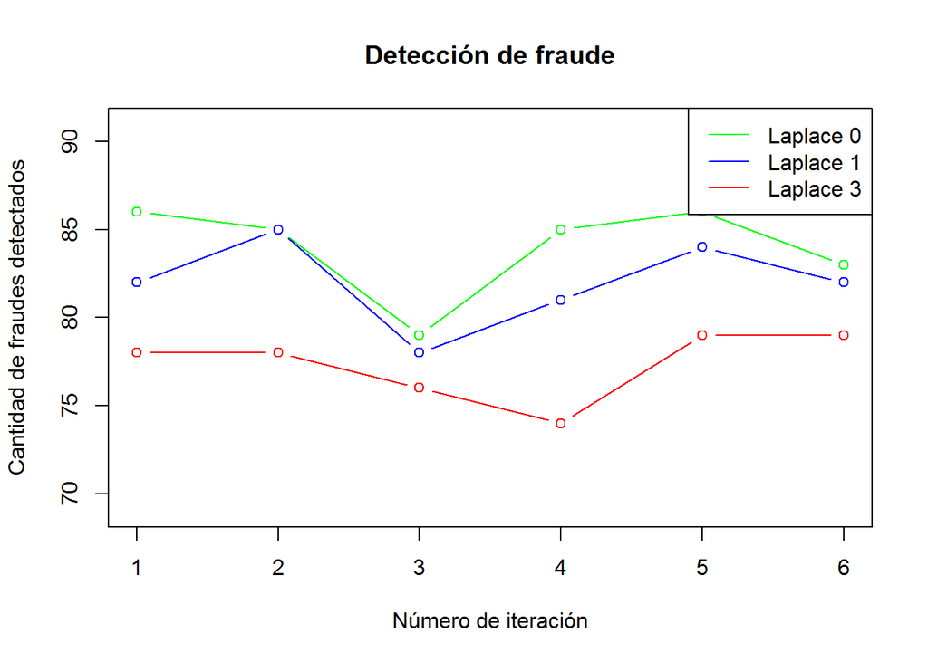

```r
plot(deteccion.mayor.laplace.0, col = "green", type = "b",  ylim = c(min(deteccion.mayor.laplace.0, deteccion.mayor.laplace.1, deteccion.mayor.laplace.3)-5, max(deteccion.mayor.laplace.0, deteccion.mayor.laplace.1, deteccion.mayor.laplace.3)+5), main = "Detección de fraude", xlab = "Número de iteración", ylab = "Cantidad de fraudes detectados")
points(deteccion.mayor.laplace.1, col = "blue", type = "b")
points(deteccion.mayor.laplace.3, col = "red", type = "b")
legend("topright", legend = c("Laplace 0","Laplace 1","Laplace 3"), col = c("green",
    "blue","red"), lty = 1, lwd = 1)
```

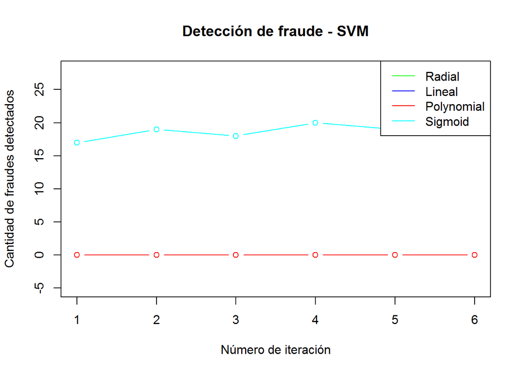

```r
plot(deteccion.mayor.radial, col = "green", type = "b",  ylim = c(min(deteccion.mayor.radial,deteccion.mayor.lineal,deteccion.mayor.polynomial,deteccion.mayor.sigmoid)-5, max(deteccion.mayor.radial,deteccion.mayor.lineal,deteccion.mayor.polynomial,deteccion.mayor.sigmoid)+5), main = "Detección de fraude - SVM", xlab = "Número de iteración", ylab = "Cantidad de fraudes detectados")
points(deteccion.mayor.lineal, col = "blue", type = "b")
points(deteccion.mayor.polynomial, col = "red", type = "b")
points(deteccion.mayor.sigmoid, col = "cyan", type = "b")
legend("topright", legend = c("Radial","Lineal","Polynomial","Sigmoid"), col = c("green",
    "blue","red","cyan"), lty = 1, lwd = 1)
```

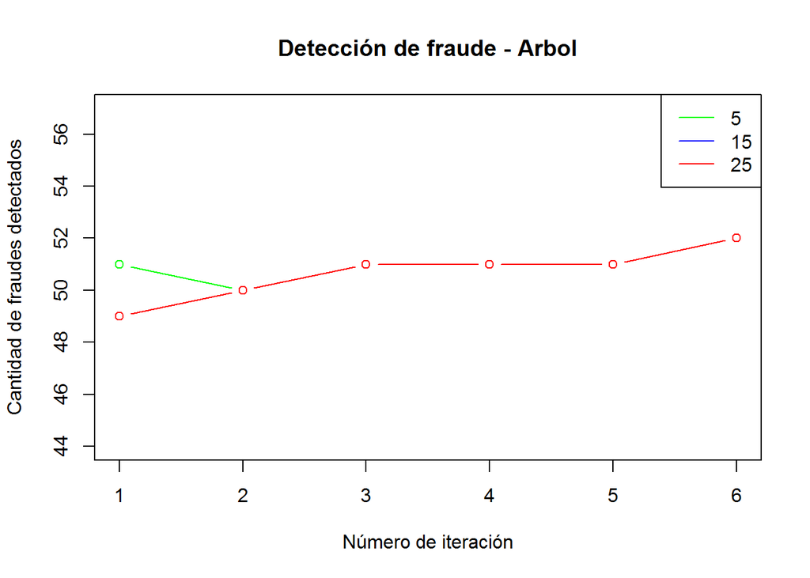

```r
plot(deteccion.mayor.arbol.1, col = "green", type = "b",  ylim = c(min(deteccion.mayor.arbol.1,deteccion.mayor.arbol.2,deteccion.mayor.arbol.3)-5, max(deteccion.mayor.arbol.1,deteccion.mayor.arbol.2,deteccion.mayor.arbol.3)+5), main = "Detección de fraude - Arbol", xlab = "Número de iteración", ylab = "Cantidad de fraudes detectados")
points(deteccion.mayor.arbol.2, col = "blue", type = "b")
points(deteccion.mayor.arbol.3, col = "red", type = "b")
legend("topright", legend = c("5","15","25"), col = c("green",
    "blue","red"), lty = 1, lwd = 1)
```

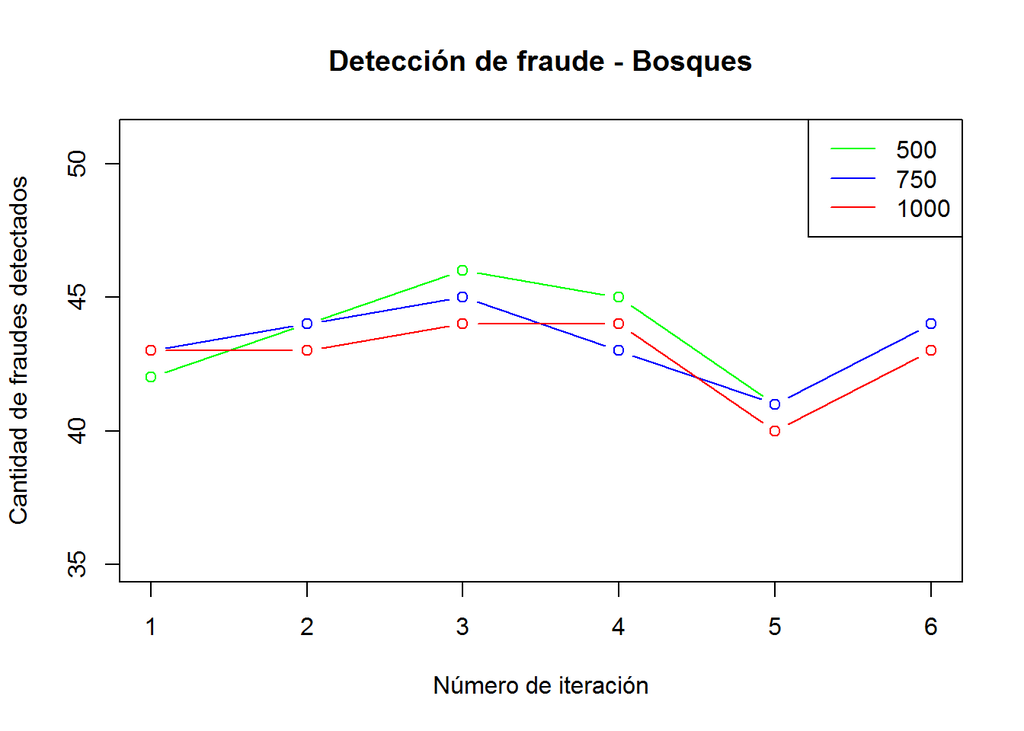

```r
plot(deteccion.mayor.bosques.500, col = "green", type = "b",  ylim = c(min(deteccion.mayor.bosques.500,deteccion.mayor.bosques.750,deteccion.mayor.bosques.1000)-5, max(deteccion.mayor.bosques.500,deteccion.mayor.bosques.750,deteccion.mayor.bosques.1000)+5), main = "Detección de fraude - Bosques", xlab = "Número de iteración", ylab = "Cantidad de fraudes detectados")
points(deteccion.mayor.bosques.750, col = "blue", type = "b")
points(deteccion.mayor.bosques.1000, col = "red", type = "b")
legend("topright", legend = c("500","750","1000"), col = c("green",
    "blue","red"), lty = 1, lwd = 1)
```

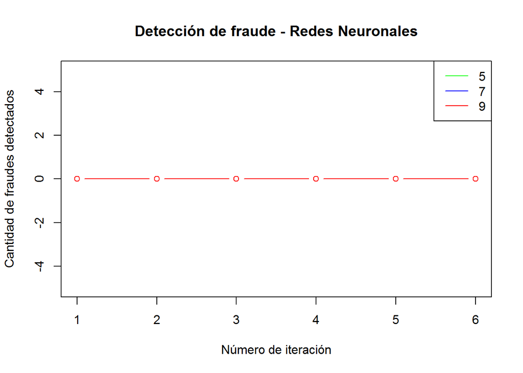

```r
plot(deteccion.mayor.redes.1, col = "green", type = "b",  ylim = c(min(deteccion.mayor.redes.1,deteccion.mayor.redes.2,deteccion.mayor.redes.3)-5, max(deteccion.mayor.redes.1,deteccion.mayor.redes.2,deteccion.mayor.redes.3)+5), main = "Detección de fraude - Redes Neuronales", xlab = "Número de iteración", ylab = "Cantidad de fraudes detectados")
points(deteccion.mayor.redes.2, col = "blue", type = "b")
points(deteccion.mayor.redes.3, col = "red", type = "b")
legend("topright", legend = c("5","7","9"), col = c("green","blue","red"), lty = 1, lwd = 1)
```

[figure not shown]

```r
plot(deteccion.mayor.k.10, col = "green", type = "b",  ylim = c(min(deteccion.mayor.k.10,deteccion.mayor.k.25,deteccion.mayor.k.50)-5, max(deteccion.mayor.k.10,deteccion.mayor.k.25,deteccion.mayor.k.50)+5), main = "Detección de fraude - K-vecinos", xlab = "Número de iteración", ylab = "Cantidad de fraudes detectados")
points(deteccion.mayor.k.25, col = "blue", type = "b")
points(deteccion.mayor.k.50, col = "red", type = "b")
legend("topright", legend = c("10","25","50"), col = c("green",
    "blue","red"), lty = 1, lwd = 1)
```

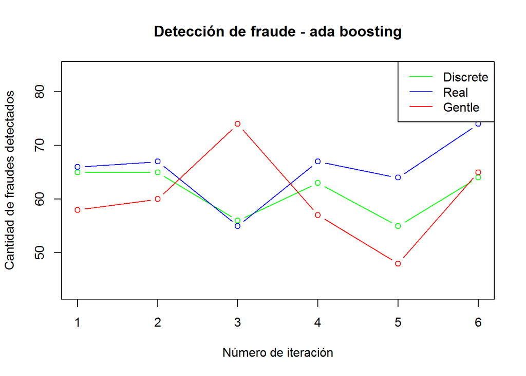

```r
plot(deteccion.mayor.discrete, col = "green", type = "b",  ylim = c(min(deteccion.mayor.discrete, deteccion.mayor.real, deteccion.mayor.gentle)-5, max(deteccion.mayor.discrete, deteccion.mayor.real, deteccion.mayor.gentle)+10), main = "Detección de fraude - ada boosting", xlab = "Número de iteración", ylab = "Cantidad de fraudes detectados")
points(deteccion.mayor.real, col = "blue", type = "b")
points(deteccion.mayor.gentle, col = "red", type = "b")
legend("topright", legend = c("Discrete","Real","Gentle"), col = c("green",
    "blue","red"), lty = 1, lwd = 1)
```

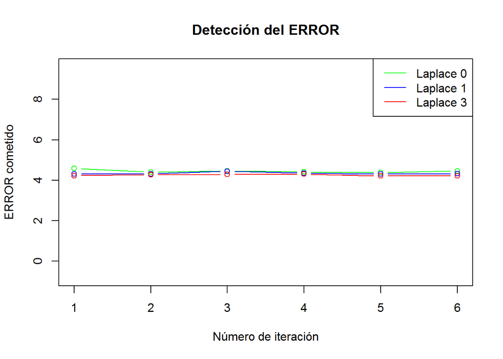

```r
plot(deteccion.error.laplace.0, col = "green", type = "b",  ylim = c(min(deteccion.error.laplace.0, deteccion.error.laplace.1, deteccion.error.laplace.3)-5, max(deteccion.error.laplace.0, deteccion.error.laplace.1, deteccion.error.laplace.3)+5), main = "Detección del ERROR", xlab = "Número de iteración", ylab = "ERROR cometido")
points(deteccion.error.laplace.1, col = "blue", type = "b")
points(deteccion.error.laplace.3, col = "red", type = "b")
legend("topright", legend = c("Laplace 0","Laplace 1","Laplace 3"), col = c("green",
    "blue","red"), lty = 1, lwd = 1)
```

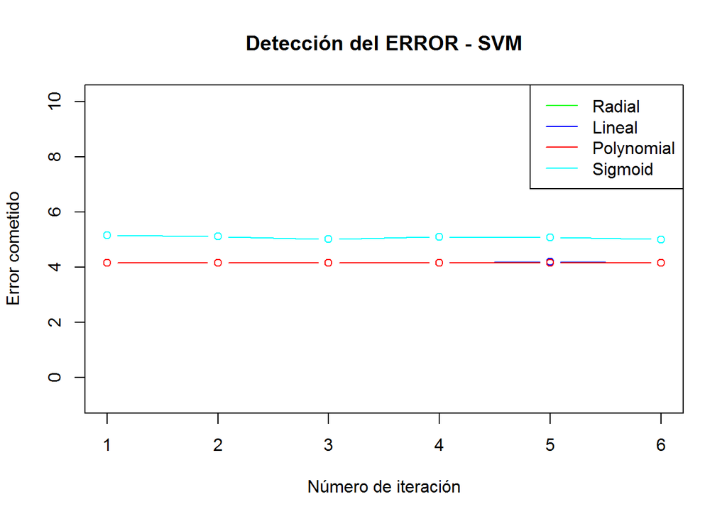

```r
plot(deteccion.error.radial, col = "green", type = "b",  ylim = c(min(deteccion.error.radial,deteccion.error.lineal,deteccion.error.polynomial,deteccion.error.sigmoid)-5, max(deteccion.error.radial,deteccion.error.lineal,deteccion.error.polynomial,deteccion.error.sigmoid)+5), main = "Detección del ERROR - SVM", xlab = "Número de iteración", ylab = "Error cometido")
points(deteccion.error.lineal, col = "blue", type = "b")
points(deteccion.error.polynomial, col = "red", type = "b")
points(deteccion.error.sigmoid, col = "cyan", type = "b")
legend("topright", legend = c("Radial","Lineal","Polynomial","Sigmoid"), col = c("green",
    "blue","red","cyan"), lty = 1, lwd = 1)
```

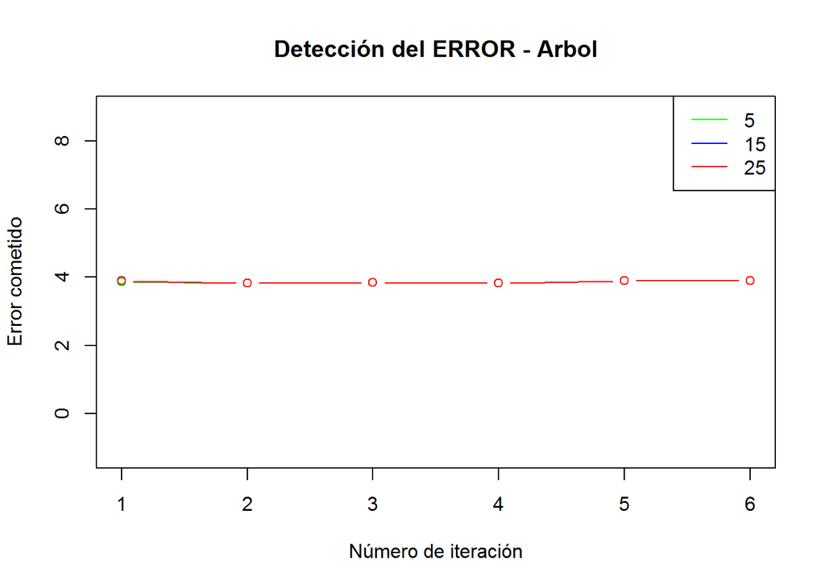

```r
plot(deteccion.error.arbol.1, col = "green", type = "b",  ylim = c(min(deteccion.error.arbol.1,deteccion.error.arbol.2,deteccion.error.arbol.3)-5, max(deteccion.error.arbol.1,deteccion.error.arbol.2,deteccion.error.arbol.3)+5), main = "Detección del ERROR - Arbol", xlab = "Número de iteración", ylab = "Error cometido")
points(deteccion.error.arbol.2, col = "blue", type = "b")
points(deteccion.error.arbol.3, col = "red", type = "b")
legend("topright", legend = c("5","15","25"), col = c("green",
    "blue","red"), lty = 1, lwd = 1)
```

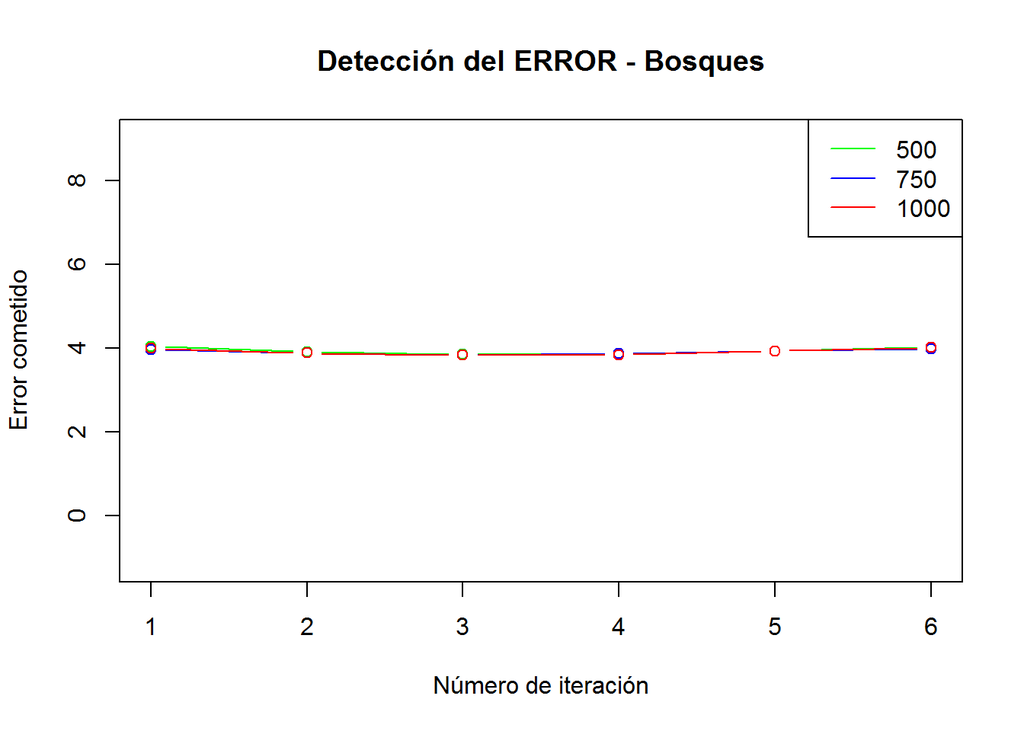

```r
plot(deteccion.error.bosques.500, col = "green", type = "b",  ylim = c(min(deteccion.error.bosques.500,deteccion.error.bosques.750,deteccion.error.bosques.1000)-5, max(deteccion.error.bosques.500,deteccion.error.bosques.750,deteccion.error.bosques.1000)+5), main = "Detección del ERROR - Bosques", xlab = "Número de iteración", ylab = "Error cometido")
points(deteccion.error.bosques.750, col = "blue", type = "b")
points(deteccion.error.bosques.1000, col = "red", type = "b")
legend("topright", legend = c("500","750","1000"), col = c("green",
    "blue","red"), lty = 1, lwd = 1)
```

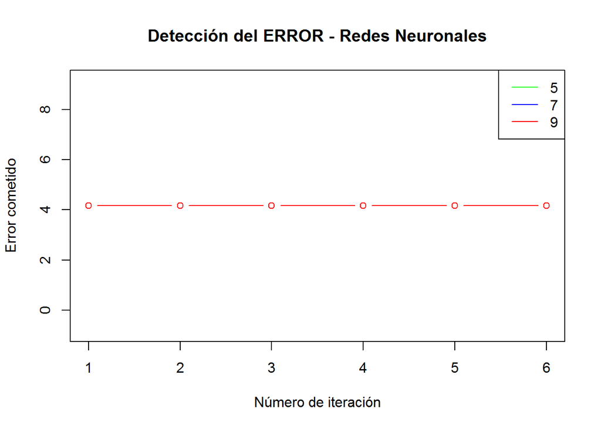

```r
plot(deteccion.error.redes.1, col = "green", type = "b",  ylim = c(min(deteccion.error.redes.1,deteccion.error.redes.2,deteccion.error.redes.3)-5, max(deteccion.error.redes.1,deteccion.error.redes.2,deteccion.error.redes.3)+5), main = "Detección del ERROR - Redes Neuronales", xlab = "Número de iteración", ylab = "Error cometido")
points(deteccion.error.redes.2, col = "blue", type = "b")
points(deteccion.error.redes.3, col = "red", type = "b")
legend("topright", legend = c("5","7","9"), col = c("green","blue","red"), lty = 1, lwd = 1)
```

[figure not shown]

```r
plot(deteccion.error.k.10, col = "green", type = "b",  ylim = c(min(deteccion.error.k.10,deteccion.error.k.25,deteccion.error.k.50)-5, max(deteccion.error.k.10,deteccion.error.k.25,deteccion.error.k.50)+5), main = "Detección del ERROR - K-vecinos", xlab = "Número de iteración", ylab = "Error cometido")
points(deteccion.error.k.25, col = "blue", type = "b")
points(deteccion.error.k.50, col = "red", type = "b")
legend("topright", legend = c("10","25","50"), col = c("green",
    "blue","red"), lty = 1, lwd = 1)
```

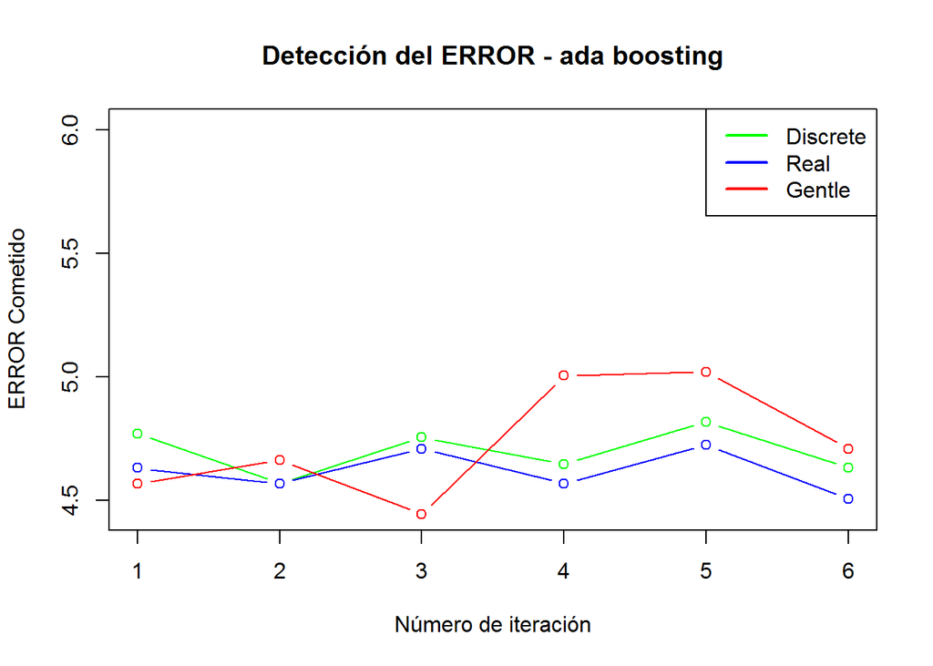

```r
plot(deteccion.error.discrete, col = "green", type = "b",  ylim = c(min(deteccion.error.discrete, deteccion.error.real, deteccion.error.gentle), max(deteccion.error.discrete, deteccion.error.real, deteccion.error.gentle)+1), main = "Detección del ERROR - ada boosting", xlab = "Número de iteración", ylab = "ERROR Cometido")
points(deteccion.error.real, col = "blue", type = "b")
points(deteccion.error.gentle, col = "red", type = "b")

legend("topright", legend = c("Discrete","Real","Gentle"), col = c("green","blue","red"), lty = 1, lwd = 2)
```

Se va a usar el modelo de Bayes que dio un mejor resultado durante la calibración.

```r
datos5 <- read.csv("SegurosNuevos500V2016VE.csv", header=TRUE, sep=";", dec=",")
modelo.bayes <- naiveBayes(Fraude~.,data=datos4,laplace=0)
Fraude <- predict(modelo.bayes,datos5)
datos5 <- cbind(datos5[,1:11],Fraude)
write.csv(datos5,"RetoAcuna.csv", row.names=TRUE, sep=";")
end.time <- Sys.time()
time.taken <- round(end.time - start.time,2)
time.taken
```

```
## Time difference of 47.49 mins
```